# Univariate TS Models

Here, we will apply the ARIMA or SARIMA model to our 10 time series datasets in order to make forecasts. Below is a brief introduction to both models, including the parameters p, d, q, P, D, and Q.

**ARIMA Model:**  
ARIMA (AutoRegressive Integrated Moving Average) is used for non-seasonal time series data that exhibit patterns over time. The parameters are:  
- **p**: The order of the autoregressive (AR) term.  
- **d**: The degree of differencing to make the series stationary.  
- **q**: The order of the moving average (MA) term.

**SARIMA Model:**  
SARIMA (Seasonal ARIMA) is an extension of the ARIMA model that deals with seasonality in time series data. The additional parameters for seasonal components are:  
- **P**: The order of the seasonal autoregressive (AR) term.  
- **D**: The degree of seasonal differencing.  
- **Q**: The order of the seasonal moving average (MA) term.  
- **s**: The number of periods in each season.

**Data and Model Selection:**  
In the [EDA phase](https://binghuini.github.io/_site_ts_usd_index/eda.html#differencing), we performed differencing and seasonal differencing to transform the original series into stationary series. The stationarity of the differenced series was validated using the Augmented Dickey-Fuller (ADF) test. Therefore, we can now decide whether to apply the ARIMA or SARIMA model and select the appropriate values for d or D.

- **U.S. Dollar Index**: First-order differencing, ARIMA model, d=1.
- **Trade Balance**: Both seasonal and ordinary differencing, SARIMA model, d=1, D=1, s=4.
- **GDP**: First-order differencing, ARIMA model, d=1.
- **Unemployment Rate**: First-order differencing, ARIMA model, d=1.
- **CPI**: Both seasonal and ordinary differencing, SARIMA model, d=1, D=1, s=12.
- **S&P 500**: First-order differencing, ARIMA model, d=1.
- **Gold Price**: First-order differencing, ARIMA model, d=1.
- **Global Commodity Price**: First-order differencing, ARIMA model, d=1.
- **House Price**: First-order differencing, ARIMA model, d=1.
- **International Visitors**: Both seasonal and ordinary differencing, SARIMA model, d=1, D=1, s=12.

After performing the necessary differencing or seasonal differencing, all series have become stationary. We will now present the ACF and PACF plots of these differenced series to determine the optimal values for p (AR model), q (MA model), P (seasonal AR), and Q (seasonal MA).

## ACF and PACF Plots

The following displays the ACF and PACF plots for the stationary series after differencing.

```r
library(ggplot2)
library(tidyverse)
library(plotly)
library(quantmod)
library(forecast)
library(astsa)

# Load data
invisible(getSymbols("DX-Y.NYB", src = "yahoo", from = "2005-01-01", to = "2024-12-31"))
dxy <- data.frame(Date = index(`DX-Y.NYB`),
                       Open = `DX-Y.NYB`[, "DX-Y.NYB.Open"],
                       High = `DX-Y.NYB`[, "DX-Y.NYB.High"],
                       Low = `DX-Y.NYB`[, "DX-Y.NYB.Low"],
                       Close = `DX-Y.NYB`[, "DX-Y.NYB.Close"])
colnames(dxy) <- c("Date", "Open", "High", "Low", "Close")
dxy <- na.omit(dxy)

bea <- read.csv("./data/bea.csv")
bea$time <- as.Date(bea$time)

gdp <- read.csv("./data/gdp.csv")
gdp$time <- as.Date(gdp$time)
gdp$total <- gdp$consumption + gdp$investment + gdp$net_export + gdp$government

data_unem <- read.csv("./data/unem.csv", header=TRUE)
data_unem$time <- as.Date(data_unem$time)

data_cpi <- read.csv("./data/cpi.csv", header=TRUE)
data_cpi$time <- as.Date(data_cpi$time)

invisible(getSymbols("^GSPC", src = "yahoo", from = "2005-01-01", to = "2024-12-31"))
data <- data.frame(Date = index(GSPC),
                       Open = GSPC[, "GSPC.Open"],
                       High = GSPC[, "GSPC.High"],
                       Low = GSPC[, "GSPC.Low"],
                       Close = GSPC[, "GSPC.Close"])
colnames(data) <- c("Date", "Open", "High", "Low", "Close")

xau <- read.csv("./data/xau.csv")
xau$Date <- as.Date(xau$Date)

gsci <- read.csv("./data/gsci.csv")
gsci$Date <- as.Date(gsci$Date)

house <- read.csv("./data/house.csv", header=TRUE)
house$time <- as.Date(house$time)

visitors <- read.csv("./data/visitors.csv", header=TRUE)
visitors$time <- as.Date(visitors$time)

# time series
dxy_ts <- ts(log(dxy$Close), start=c(2005,1), frequency=252)
balance_ts <- ts(bea$balance, start=c(2005,1), end=c(2024,3), frequency=4)
gdp_ts <- ts(gdp$total, start=c(2005,1), end=c(2024,3), frequency=4)
unem_ts <- ts(log(data_unem$unem), start=c(2005,1), end=c(2023,12), frequency=12)
cpi_ts <- ts(data_cpi$cpi, start=c(2005,1), end=c(2023,12), frequency=12)
sp5_ts <- ts(GSPC$GSPC.Close, start=c(2005,1), frequency=252)
xau_ts <- ts(log(xau$Price), start=c(2005,1), end=c(2024,52), frequency=52)
gsci_ts <- ts(log(gsci$Price), start=c(2014,252), frequency=252)
house_ts <- ts(house$index, start=c(2005,1), end=c(2024,4), frequency=4)
visitors_ts <- ts(log(visitors$count), start=c(2005,1), end=c(2024,12), frequency=12)
```

**U.S. Dollar Index**

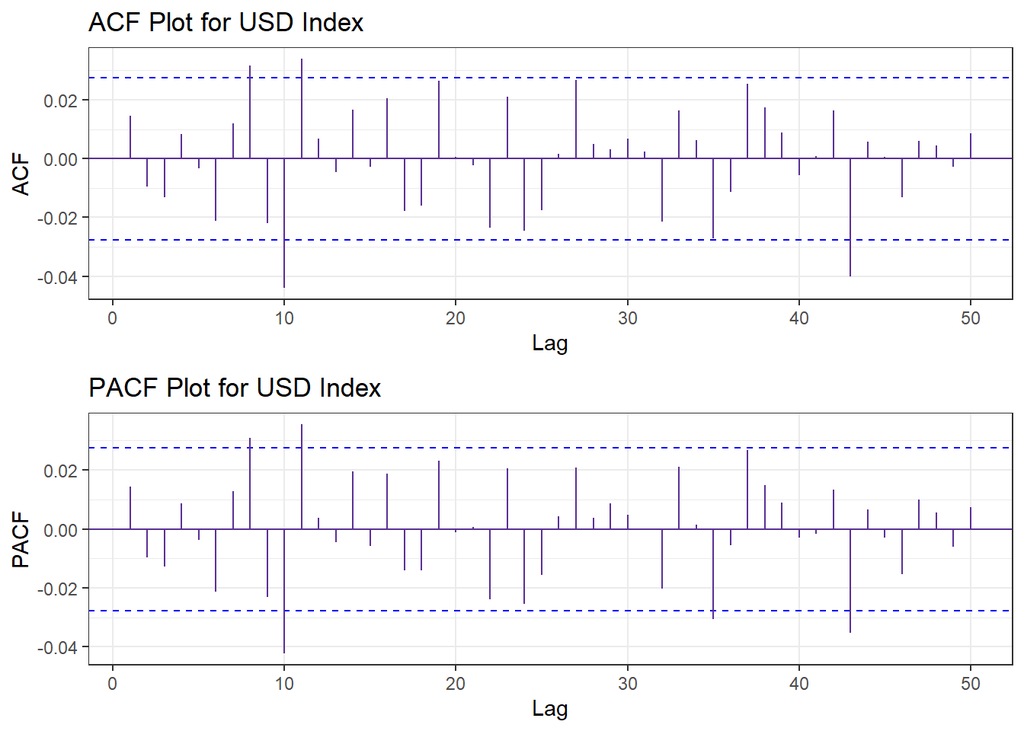

```r
library(gridExtra)

acf <- ggAcf(diff(dxy_ts), 50)+ggtitle("ACF Plot for USD Index") + theme_bw()+
  geom_segment(lineend = "butt", color = "#5a3196") +
    geom_hline(yintercept = 0, color = "#5a3196")
pacf <- ggPacf(diff(dxy_ts), 50)+ggtitle("PACF Plot for USD Index") + theme_bw()+
  geom_segment(lineend = "butt", color = "#5a3196") +
    geom_hline(yintercept = 0, color = "#5a3196")
grid.arrange(acf, pacf, nrow=2)
```

**Trade Balance**

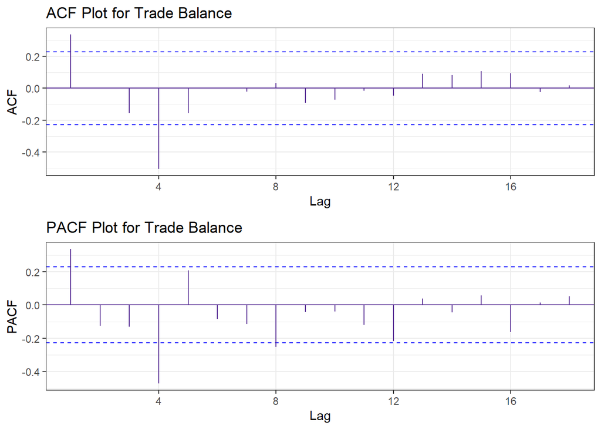

```r
acf <- ggAcf(diff(diff(balance_ts, lag=4)))+ggtitle("ACF Plot for Trade Balance") + theme_bw()+
  geom_segment(lineend = "butt", color = "#5a3196") +
    geom_hline(yintercept = 0, color = "#5a3196")
pacf <- ggPacf(diff(diff(balance_ts, lag=4)))+ggtitle("PACF Plot for Trade Balance") + theme_bw()+
  geom_segment(lineend = "butt", color = "#5a3196") +
    geom_hline(yintercept = 0, color = "#5a3196")
grid.arrange(acf, pacf, nrow=2)
```

**GDP**

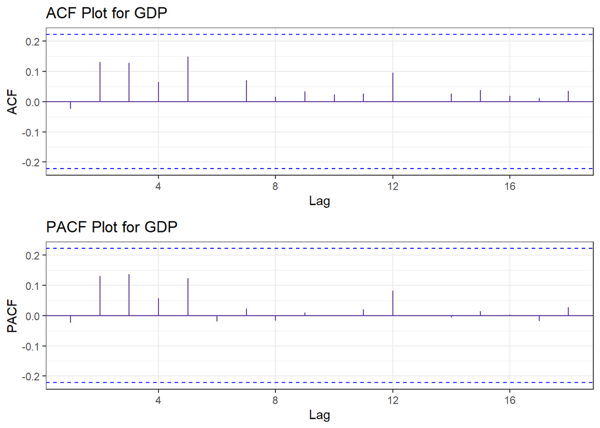

```r
acf <- ggAcf(diff(gdp_ts))+ggtitle("ACF Plot for GDP") + theme_bw()+
  geom_segment(lineend = "butt", color = "#5a3196") +
    geom_hline(yintercept = 0, color = "#5a3196")
pacf <- ggPacf(diff(gdp_ts))+ggtitle("PACF Plot for GDP") + theme_bw()+
  geom_segment(lineend = "butt", color = "#5a3196") +
    geom_hline(yintercept = 0, color = "#5a3196")
grid.arrange(acf, pacf, nrow=2)
```

**Unemployment Rate**

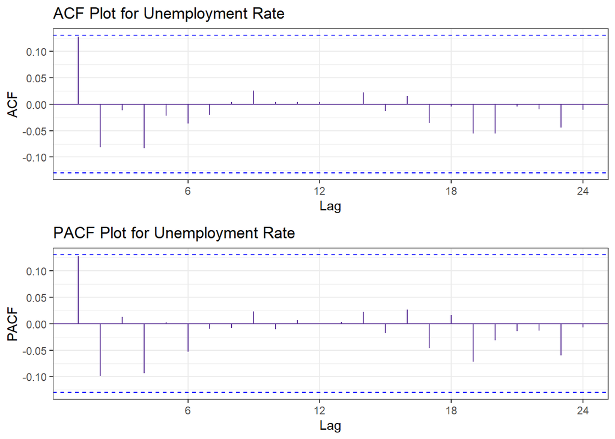

```r
acf <- ggAcf(diff(unem_ts))+ggtitle("ACF Plot for Unemployment Rate") + theme_bw()+
  geom_segment(lineend = "butt", color = "#5a3196") +
    geom_hline(yintercept = 0, color = "#5a3196")
pacf <- ggPacf(diff(unem_ts))+ggtitle("PACF Plot for Unemployment Rate") + theme_bw()+
  geom_segment(lineend = "butt", color = "#5a3196") +
    geom_hline(yintercept = 0, color = "#5a3196")
grid.arrange(acf, pacf, nrow=2)
```

**CPI**

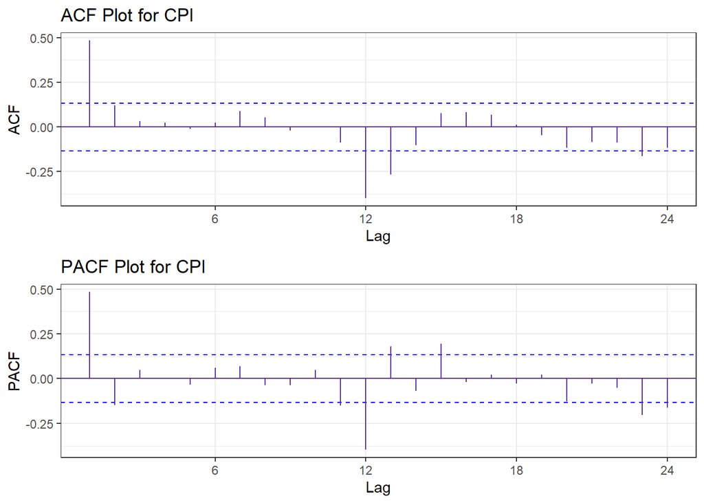

```r
acf <- ggAcf(diff(diff(cpi_ts, lag=12)))+ggtitle("ACF Plot for CPI") + theme_bw()+
  geom_segment(lineend = "butt", color = "#5a3196") +
    geom_hline(yintercept = 0, color = "#5a3196")
pacf <- ggPacf(diff(diff(cpi_ts, lag=12)))+ggtitle("PACF Plot for CPI") + theme_bw()+
  geom_segment(lineend = "butt", color = "#5a3196") +
    geom_hline(yintercept = 0, color = "#5a3196")
grid.arrange(acf, pacf, nrow=2)
```

**S&P 500**

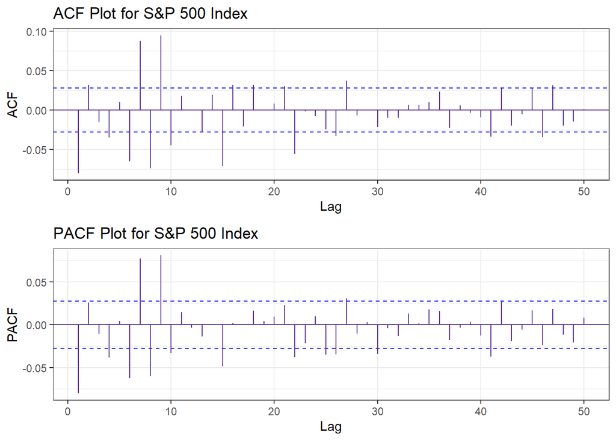

```r
acf <- ggAcf(diff(sp5_ts), 50)+ggtitle("ACF Plot for S&P 500 Index") + theme_bw()+
  geom_segment(lineend = "butt", color = "#5a3196") +
    geom_hline(yintercept = 0, color = "#5a3196")
pacf <- ggPacf(diff(sp5_ts), 50)+ggtitle("PACF Plot for S&P 500 Index") + theme_bw()+
  geom_segment(lineend = "butt", color = "#5a3196") +
    geom_hline(yintercept = 0, color = "#5a3196")
grid.arrange(acf, pacf, nrow=2)
```

**Gold Price**

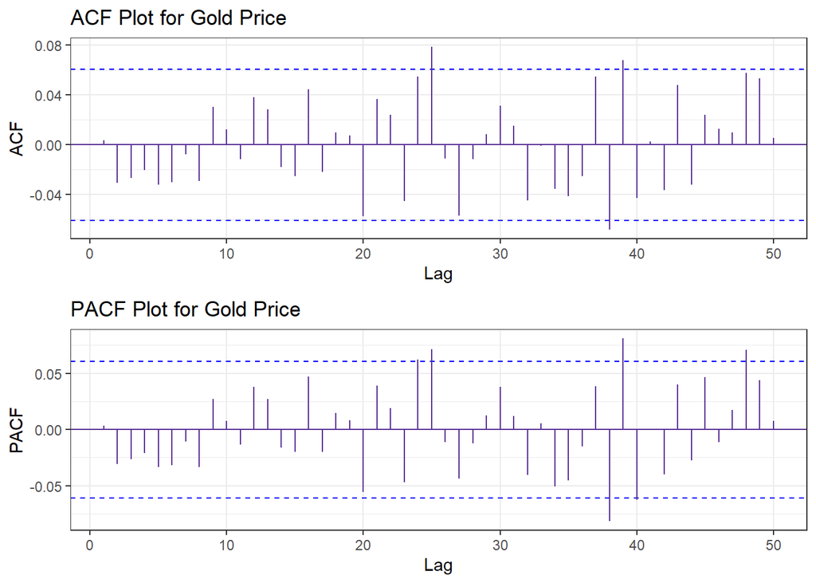

```r
acf <- ggAcf(diff(xau_ts), 50)+ggtitle("ACF Plot for Gold Price") + theme_bw()+
  geom_segment(lineend = "butt", color = "#5a3196") +
    geom_hline(yintercept = 0, color = "#5a3196")
pacf <- ggPacf(diff(xau_ts), 50)+ggtitle("PACF Plot for Gold Price") + theme_bw()+
  geom_segment(lineend = "butt", color = "#5a3196") +
    geom_hline(yintercept = 0, color = "#5a3196")
grid.arrange(acf, pacf, nrow=2)
```

**Global Commodity Price**

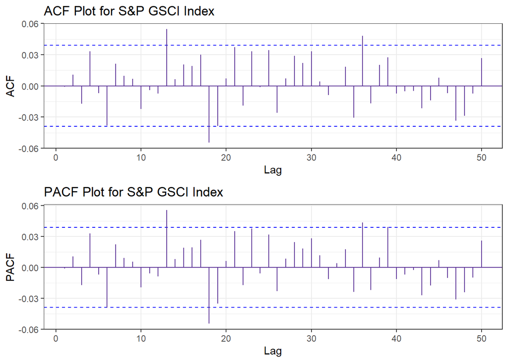

```r
acf <- ggAcf(diff(gsci_ts), 50)+ggtitle("ACF Plot for S&P GSCI Index") + theme_bw()+
  geom_segment(lineend = "butt", color = "#5a3196") +
    geom_hline(yintercept = 0, color = "#5a3196")
pacf <- ggPacf(diff(gsci_ts), 50)+ggtitle("PACF Plot for S&P GSCI Index") + theme_bw()+
  geom_segment(lineend = "butt", color = "#5a3196") +
    geom_hline(yintercept = 0, color = "#5a3196")
grid.arrange(acf, pacf, nrow=2)
```

**House Price**

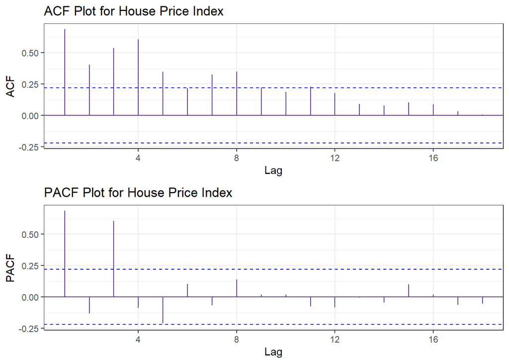

```r
acf <- ggAcf(diff(house_ts))+ggtitle("ACF Plot for House Price Index") + theme_bw()+
  geom_segment(lineend = "butt", color = "#5a3196") +
    geom_hline(yintercept = 0, color = "#5a3196")
pacf <- ggPacf(diff(house_ts))+ggtitle("PACF Plot for House Price Index") + theme_bw()+
  geom_segment(lineend = "butt", color = "#5a3196") +
    geom_hline(yintercept = 0, color = "#5a3196")
grid.arrange(acf, pacf, nrow=2)
```

**International Visitors**

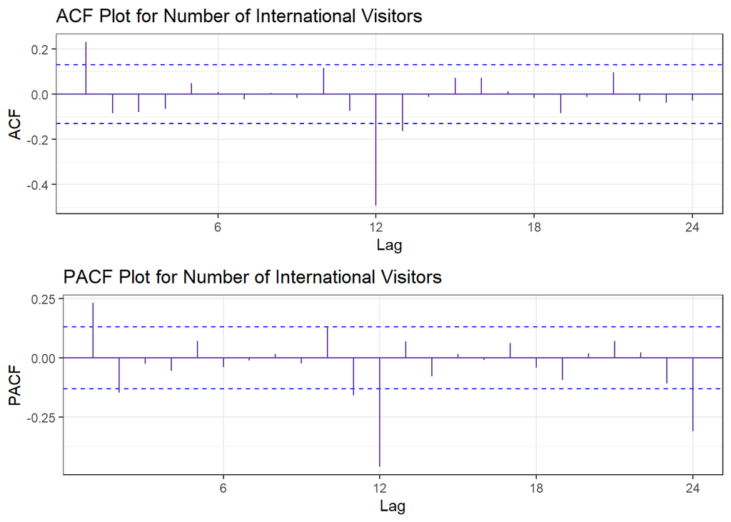

```r
acf <- ggAcf(diff(diff(visitors_ts, lag=12)))+ggtitle("ACF Plot for Number of International Visitors") + theme_bw()+
  geom_segment(lineend = "butt", color = "#5a3196") +
    geom_hline(yintercept = 0, color = "#5a3196")
pacf <- ggPacf(diff(diff(visitors_ts, lag=12)))+ggtitle("PACF Plot for Number of International Visitors") + theme_bw()+
  geom_segment(lineend = "butt", color = "#5a3196") +
    geom_hline(yintercept = 0, color = "#5a3196")
grid.arrange(acf, pacf, nrow=2)
```

The ACF plot helps determine the q parameter by identifying the number of significant lags in the moving average (MA) component. The PACF plot helps determine the p parameter by identifying the number of significant lags in the autoregressive (AR) component. For seasonal models, ACF and PACF can also be used to determine the seasonal parameters Q and P.

- **U.S. Dollar Index**: ARIMA model, p=0, d=1, q=0.
- **Trade Balance**: SARIMA model, p=1, d=1, q=1, P=1 or 2，D=1, Q=1, s=4.
- **GDP**: ARIMA model, p=0, d=1, q=0.
- **Unemployment Rate**: ARIMA model, p=0 or 1, d=1, q=0 or 1.
- **CPI**: SARIMA model, p=1 or 2, d=1, q=1 or 2, P=1 or 2, D=1, Q=1 or 2, s=12.
- **S&P 500**: ARIMA model, p=0 or 1 or 4, d=1, q=0:4.
- **Gold Price**: ARIMA model, p=0:4, d=1, q=0:4.
- **Global Commodity Price**: ARIMA model, p=0:4, d=1, q=0:4.
- **House Price**: ARIMA model, p=1 or 3, d=1, q=0:4.
- **International Visitors**: SARIMA model, p=1 or 2, d=1, q=1, P=1 or 2, D=1, Q=1, s=12.

## Model Selection by Manual Search

Write a function

```r
set.seed(123)
library(kableExtra)

#write a funtion
ARIMA.c = function(p1, p2, q1, q2, data) {
  d = 1
  i = 1
  temp = data.frame()
  ls = matrix(rep(NA, 6 * 100), nrow = 100)

  for (p in p1:p2) {
    for (q in q1:q2) {
          if (p + d + q <= 9) {

            model <- tryCatch({
              Arima(data, order = c(p, d, q), include.drift = TRUE)
            }, error = function(e) {
              return(NULL)
            })

            if (!is.null(model)) {
              ls[i, ] = c(p, d, q, model$aic, model$bic, model$aicc)
              i = i + 1
            }
          }
        }
      }
      temp = as.data.frame(ls)
      names(temp) = c("p", "d", "q", "AIC", "BIC", "AICc")
      temp = na.omit(temp)
      return(temp)
}

SARIMA.c = function(p1, p2, q1, q2, P1, P2, Q1, Q2, s, data) {
  d = 1
  D = 1
  i = 1
  temp = data.frame()
  ls = matrix(rep(NA, 9 * 100), nrow = 100)

  for (p in p1:p2) {
    for (q in q1:q2) {
      for (P in P1:P2) {
        for (Q in Q1:Q2) {
          if (p + d + q + P + D + Q <= 9) {

            model <- tryCatch({
              Arima(data, order = c(p, d, q), seasonal = list(order = c(P,D,Q), period = s))
            }, error = function(e) {
              return(NULL)
            })

            if (!is.null(model)) {
              ls[i, ] = c(p, d, q, P, D, Q, model$aic, model$bic, model$aicc)
              i = i + 1
            }
          }
        }
      }
    }
  }

  temp = as.data.frame(ls)
  names(temp) = c("p", "d", "q", "P", "D", "Q", "AIC", "BIC", "AICc")
  temp = na.omit(temp)
  return(temp)
}

highlight_output = function(output, type="ARIMA") {
    highlight_row <- c(which.min(output$AIC), which.min(output$BIC), which.min(output$AICc))
    knitr::kable(output, align = 'c', caption = paste("Comparison of", type, "Models")) %>%
    kable_styling(full_width = FALSE, position = "center") %>%
    row_spec(highlight_row, bold = TRUE, background = "#FFFF99")  # Highlight row in yellow
}
```

**U.S. Dollar Index**

```r
output=ARIMA.c(p1=0,p2=3,q1=0,q2=3,data=dxy_ts)
highlight_output(output)
```

Comparison of ARIMA Models

| p | d | q | AIC | BIC | AICc |
| --- | --- | --- | --- | --- | --- |
| 0 | 1 | 0 | -39549.01 | -39535.96 | -39549.01 |
| 0 | 1 | 1 | -39548.08 | -39528.51 | -39548.08 |
| 0 | 1 | 2 | -39546.49 | -39520.39 | -39546.48 |
| 0 | 1 | 3 | -39545.42 | -39512.80 | -39545.41 |
| 1 | 1 | 0 | -39548.06 | -39528.49 | -39548.06 |
| 1 | 1 | 1 | -39546.07 | -39519.98 | -39546.06 |
| 1 | 1 | 2 | -39544.50 | -39511.87 | -39544.48 |
| 1 | 1 | 3 | -39543.41 | -39504.27 | -39543.40 |
| 2 | 1 | 0 | -39546.53 | -39520.43 | -39546.52 |
| 2 | 1 | 1 | -39544.52 | -39511.90 | -39544.51 |
| 2 | 1 | 2 | -39542.13 | -39502.98 | -39542.11 |
| 2 | 1 | 3 | -39541.32 | -39495.65 | -39541.30 |
| 3 | 1 | 0 | -39545.35 | -39512.73 | -39545.34 |
| 3 | 1 | 1 | -39543.36 | -39504.21 | -39543.34 |
| 3 | 1 | 2 | -39541.22 | -39495.55 | -39541.20 |
| 3 | 1 | 3 | -39556.18 | -39503.98 | -39556.15 |

**Trade Balance**

```r
output=SARIMA.c(p1=0, p2=1, q1=0, q2=1, P1=0, P2=3, Q1=0, Q2=1, s=4, data=balance_ts)
highlight_output(output, type="SARIMA")
```

Comparison of SARIMA Models

| p | d | q | P | D | Q | AIC | BIC | AICc |
| --- | --- | --- | --- | --- | --- | --- | --- | --- |
| 0 | 1 | 0 | 0 | 1 | 0 | 1687.645 | 1689.949 | 1687.700 |
| 0 | 1 | 0 | 0 | 1 | 1 | 1643.862 | 1648.470 | 1644.031 |
| 0 | 1 | 0 | 1 | 1 | 0 | 1666.255 | 1670.863 | 1666.424 |
| 0 | 1 | 0 | 1 | 1 | 1 | 1645.239 | 1652.151 | 1645.582 |
| 0 | 1 | 0 | 2 | 1 | 0 | 1658.611 | 1665.523 | 1658.954 |
| 0 | 1 | 0 | 2 | 1 | 1 | 1647.203 | 1656.419 | 1647.783 |
| 0 | 1 | 0 | 3 | 1 | 0 | 1650.613 | 1659.830 | 1651.193 |
| 0 | 1 | 0 | 3 | 1 | 1 | 1649.202 | 1660.722 | 1650.084 |
| 0 | 1 | 1 | 0 | 1 | 0 | 1678.825 | 1683.434 | 1678.994 |
| 0 | 1 | 1 | 0 | 1 | 1 | 1637.189 | 1644.102 | 1637.532 |
| 0 | 1 | 1 | 1 | 1 | 0 | 1656.478 | 1663.390 | 1656.821 |
| 0 | 1 | 1 | 1 | 1 | 1 | 1638.874 | 1648.090 | 1639.453 |
| 0 | 1 | 1 | 2 | 1 | 0 | 1652.233 | 1661.449 | 1652.813 |
| 0 | 1 | 1 | 2 | 1 | 1 | 1640.824 | 1652.344 | 1641.706 |
| 0 | 1 | 1 | 3 | 1 | 0 | 1646.400 | 1657.920 | 1647.282 |
| 0 | 1 | 1 | 3 | 1 | 1 | 1642.683 | 1656.507 | 1643.937 |
| 1 | 1 | 0 | 0 | 1 | 0 | 1680.584 | 1685.192 | 1680.753 |
| 1 | 1 | 0 | 0 | 1 | 1 | 1639.372 | 1646.284 | 1639.715 |
| 1 | 1 | 0 | 1 | 1 | 0 | 1658.657 | 1665.569 | 1659.000 |
| 1 | 1 | 0 | 1 | 1 | 1 | 1641.150 | 1650.366 | 1641.729 |
| 1 | 1 | 0 | 2 | 1 | 0 | 1653.976 | 1663.192 | 1654.556 |
| 1 | 1 | 0 | 2 | 1 | 1 | 1643.099 | 1654.619 | 1643.981 |
| 1 | 1 | 0 | 3 | 1 | 0 | 1648.544 | 1660.064 | 1649.426 |
| 1 | 1 | 0 | 3 | 1 | 1 | 1645.038 | 1658.863 | 1646.292 |
| 1 | 1 | 1 | 0 | 1 | 0 | 1671.973 | 1678.885 | 1672.316 |
| 1 | 1 | 1 | 0 | 1 | 1 | 1638.738 | 1647.954 | 1639.317 |
| 1 | 1 | 1 | 1 | 1 | 0 | 1658.386 | 1667.602 | 1658.966 |
| 1 | 1 | 1 | 1 | 1 | 1 | 1640.466 | 1651.987 | 1641.349 |
| 1 | 1 | 1 | 2 | 1 | 0 | 1653.958 | 1665.478 | 1654.840 |
| 1 | 1 | 1 | 2 | 1 | 1 | 1642.453 | 1656.277 | 1643.707 |
| 1 | 1 | 1 | 3 | 1 | 0 | 1647.627 | 1661.452 | 1648.881 |
| 1 | 1 | 1 | 3 | 1 | 1 | 1644.310 | 1660.438 | 1646.007 |

**GDP**

```r
output=ARIMA.c(p1=0,p2=3,q1=0,q2=3,data=gdp_ts)
highlight_output(output)
```

Comparison of ARIMA Models

| p | d | q | AIC | BIC | AICc |
| --- | --- | --- | --- | --- | --- |
| 0 | 1 | 0 | 1134.101 | 1138.814 | 1134.261 |
| 0 | 1 | 1 | 1136.067 | 1143.137 | 1136.391 |
| 0 | 1 | 2 | 1136.765 | 1146.192 | 1137.313 |
| 0 | 1 | 3 | 1137.904 | 1149.687 | 1138.737 |
| 1 | 1 | 0 | 1136.058 | 1143.128 | 1136.382 |
| 1 | 1 | 1 | 1137.910 | 1147.337 | 1138.458 |
| 1 | 1 | 2 | 1136.451 | 1148.235 | 1137.284 |
| 1 | 1 | 3 | 1138.449 | 1152.589 | 1139.632 |
| 2 | 1 | 0 | 1136.759 | 1146.186 | 1137.307 |
| 2 | 1 | 1 | 1136.479 | 1148.262 | 1137.312 |
| 2 | 1 | 2 | 1138.450 | 1152.590 | 1139.633 |
| 2 | 1 | 3 | 1140.223 | 1156.720 | 1141.823 |
| 3 | 1 | 0 | 1137.340 | 1149.124 | 1138.174 |
| 3 | 1 | 1 | 1138.434 | 1152.575 | 1139.618 |
| 3 | 1 | 2 | 1140.093 | 1156.590 | 1141.693 |
| 3 | 1 | 3 | 1141.938 | 1160.791 | 1144.025 |

**Unemployment Rate**

```r
output=ARIMA.c(p1=0,p2=3,q1=0,q2=3,data=unem_ts)
highlight_output(output)
```

Comparison of ARIMA Models

| p | d | q | AIC | BIC | AICc |
| --- | --- | --- | --- | --- | --- |
| 0 | 1 | 0 | -446.2086 | -439.3587 | -446.1551 |
| 0 | 1 | 1 | -448.7059 | -438.4310 | -448.5983 |
| 0 | 1 | 2 | -448.6860 | -434.9862 | -448.5058 |
| 0 | 1 | 3 | -446.7116 | -429.5868 | -446.4401 |
| 1 | 1 | 0 | -447.8811 | -437.6062 | -447.7735 |
| 1 | 1 | 1 | -449.1818 | -435.4820 | -449.0016 |
| 1 | 1 | 2 | -447.1818 | -430.0570 | -446.9103 |
| 1 | 1 | 3 | -445.2603 | -424.7106 | -444.8785 |
| 2 | 1 | 0 | -448.1008 | -434.4010 | -447.9206 |
| 2 | 1 | 1 | -447.1818 | -430.0571 | -446.9103 |
| 2 | 1 | 2 | -448.5442 | -427.9945 | -448.1624 |
| 2 | 1 | 3 | -446.6341 | -422.6594 | -446.1227 |
| 3 | 1 | 0 | -446.1389 | -429.0141 | -445.8674 |
| 3 | 1 | 1 | -445.2760 | -424.7263 | -444.8942 |
| 3 | 1 | 2 | -446.6353 | -422.6606 | -446.1239 |
| 3 | 1 | 3 | -444.5934 | -417.1938 | -443.9328 |

**CPI**

```r
output=SARIMA.c(p1=0, p2=2, q1=0, q2=2, P1=0, P2=2, Q1=0, Q2=2, s=12, data=cpi_ts)
highlight_output(output, type="SARIMA")
```

Comparison of SARIMA Models

| p | d | q | P | D | Q | AIC | BIC | AICc |
| --- | --- | --- | --- | --- | --- | --- | --- | --- |
| 0 | 1 | 0 | 0 | 1 | 0 | 658.6535 | 662.0241 | 658.6723 |
| 0 | 1 | 0 | 0 | 1 | 1 | 564.1015 | 570.8427 | 564.1581 |
| 0 | 1 | 0 | 0 | 1 | 2 | 565.4134 | 575.5253 | 565.5272 |
| 0 | 1 | 0 | 1 | 1 | 0 | 617.2403 | 623.9816 | 617.2970 |
| 0 | 1 | 0 | 1 | 1 | 1 | 565.5610 | 575.6729 | 565.6747 |
| 0 | 1 | 0 | 1 | 1 | 2 | 566.7002 | 580.1828 | 566.8907 |
| 0 | 1 | 0 | 2 | 1 | 0 | 587.3352 | 597.4471 | 587.4489 |
| 0 | 1 | 0 | 2 | 1 | 1 | 565.7886 | 579.2712 | 565.9791 |
| 0 | 1 | 0 | 2 | 1 | 2 | 567.7341 | 584.5873 | 568.0212 |
| 0 | 1 | 1 | 0 | 1 | 0 | 602.0990 | 608.8402 | 602.1556 |
| 0 | 1 | 1 | 0 | 1 | 1 | 496.5890 | 506.7009 | 496.7028 |
| 0 | 1 | 1 | 0 | 1 | 2 | 498.5221 | 512.0047 | 498.7126 |
| 0 | 1 | 1 | 1 | 1 | 0 | 549.9327 | 560.0447 | 550.0465 |
| 0 | 1 | 1 | 1 | 1 | 1 | 498.5327 | 512.0153 | 498.7232 |
| 0 | 1 | 1 | 1 | 1 | 2 | 500.5890 | 517.4422 | 500.8761 |
| 0 | 1 | 1 | 2 | 1 | 0 | 523.8556 | 537.3381 | 524.0461 |
| 0 | 1 | 1 | 2 | 1 | 1 | 499.6569 | 516.5101 | 499.9440 |
| 0 | 1 | 1 | 2 | 1 | 2 | 501.2088 | 521.4326 | 501.6127 |
| 0 | 1 | 2 | 0 | 1 | 0 | 599.6907 | 609.8026 | 599.8044 |
| 0 | 1 | 2 | 0 | 1 | 1 | 494.2850 | 507.7675 | 494.4755 |
| 0 | 1 | 2 | 0 | 1 | 2 | 496.2307 | 513.0839 | 496.5178 |
| 0 | 1 | 2 | 1 | 1 | 0 | 547.4384 | 560.9210 | 547.6289 |
| 0 | 1 | 2 | 1 | 1 | 1 | 496.2386 | 513.0918 | 496.5257 |
| 0 | 1 | 2 | 1 | 1 | 2 | 498.2849 | 518.5087 | 498.6888 |
| 0 | 1 | 2 | 2 | 1 | 0 | 522.9439 | 539.7971 | 523.2310 |
| 0 | 1 | 2 | 2 | 1 | 1 | 497.4835 | 517.7073 | 497.8873 |
| 0 | 1 | 2 | 2 | 1 | 2 | 500.2385 | 523.8330 | 500.7796 |
| 1 | 1 | 0 | 0 | 1 | 0 | 603.0126 | 609.7538 | 603.0692 |
| 1 | 1 | 0 | 0 | 1 | 1 | 496.0501 | 506.1620 | 496.1639 |
| 1 | 1 | 0 | 0 | 1 | 2 | 497.9731 | 511.4557 | 498.1636 |
| 1 | 1 | 0 | 1 | 1 | 0 | 553.9797 | 564.0916 | 554.0934 |
| 1 | 1 | 0 | 1 | 1 | 1 | 497.9887 | 511.4713 | 498.1792 |
| 1 | 1 | 0 | 1 | 1 | 2 | 500.0198 | 516.8730 | 500.3069 |
| 1 | 1 | 0 | 2 | 1 | 0 | 527.9067 | 541.3892 | 528.0971 |
| 1 | 1 | 0 | 2 | 1 | 1 | 498.4834 | 515.3365 | 498.7704 |
| 1 | 1 | 0 | 2 | 1 | 2 | 499.8364 | 520.0603 | 500.2403 |
| 1 | 1 | 1 | 0 | 1 | 0 | 599.8505 | 609.9624 | 599.9642 |
| 1 | 1 | 1 | 0 | 1 | 1 | 493.2341 | 506.7166 | 493.4245 |
| 1 | 1 | 1 | 0 | 1 | 2 | 495.1292 | 511.9824 | 495.4163 |
| 1 | 1 | 1 | 1 | 1 | 0 | 547.4658 | 560.9484 | 547.6563 |
| 1 | 1 | 1 | 1 | 1 | 1 | 495.1458 | 511.9990 | 495.4329 |
| 1 | 1 | 1 | 1 | 1 | 2 | 497.2322 | 517.4561 | 497.6361 |
| 1 | 1 | 1 | 2 | 1 | 0 | 522.6196 | 539.4728 | 522.9066 |
| 1 | 1 | 1 | 2 | 1 | 1 | 496.2410 | 516.4649 | 496.6449 |
| 1 | 1 | 1 | 2 | 1 | 2 | 497.8764 | 521.4708 | 498.4174 |
| 1 | 1 | 2 | 0 | 1 | 0 | 601.6888 | 615.1714 | 601.8793 |
| 1 | 1 | 2 | 0 | 1 | 1 | 489.1427 | 505.9959 | 489.4298 |
| 1 | 1 | 2 | 0 | 1 | 2 | 490.3504 | 510.5742 | 490.7542 |
| 1 | 1 | 2 | 1 | 1 | 0 | 549.1670 | 566.0202 | 549.4541 |
| 1 | 1 | 2 | 1 | 1 | 1 | 490.5057 | 510.7295 | 490.9096 |
| 1 | 1 | 2 | 1 | 1 | 2 | 490.7902 | 514.3847 | 491.3313 |
| 1 | 1 | 2 | 2 | 1 | 0 | 523.1811 | 543.4049 | 523.5849 |
| 1 | 1 | 2 | 2 | 1 | 1 | 490.9600 | 514.5545 | 491.5011 |
| 1 | 1 | 2 | 2 | 1 | 2 | 492.1886 | 519.1537 | 492.8877 |
| 2 | 1 | 0 | 0 | 1 | 0 | 600.1804 | 610.2923 | 600.2941 |
| 2 | 1 | 0 | 0 | 1 | 1 | 495.2469 | 508.7294 | 495.4374 |
| 2 | 1 | 0 | 0 | 1 | 2 | 497.1964 | 514.0496 | 497.4835 |
| 2 | 1 | 0 | 1 | 1 | 0 | 549.5725 | 563.0551 | 549.7630 |
| 2 | 1 | 0 | 1 | 1 | 1 | 497.2053 | 514.0585 | 497.4924 |
| 2 | 1 | 0 | 1 | 1 | 2 | 499.2351 | 519.4589 | 499.6389 |
| 2 | 1 | 0 | 2 | 1 | 0 | 524.8195 | 541.6727 | 525.1066 |
| 2 | 1 | 0 | 2 | 1 | 1 | 498.0705 | 518.2943 | 498.4743 |
| 2 | 1 | 0 | 2 | 1 | 2 | 499.6220 | 523.2165 | 500.1630 |
| 2 | 1 | 1 | 0 | 1 | 0 | 601.7994 | 615.2820 | 601.9899 |
| 2 | 1 | 1 | 0 | 1 | 1 | 494.5859 | 511.4391 | 494.8730 |
| 2 | 1 | 1 | 0 | 1 | 2 | 496.3847 | 516.6086 | 496.7886 |
| 2 | 1 | 1 | 1 | 1 | 0 | 549.4650 | 566.3181 | 549.7520 |
| 2 | 1 | 1 | 1 | 1 | 1 | 496.4203 | 516.6442 | 496.8242 |
| 2 | 1 | 1 | 1 | 1 | 2 | 497.5523 | 521.1468 | 498.0934 |
| 2 | 1 | 1 | 2 | 1 | 0 | 521.3671 | 541.5910 | 521.7710 |
| 2 | 1 | 1 | 2 | 1 | 1 | 497.3314 | 520.9259 | 497.8725 |
| 2 | 1 | 1 | 2 | 1 | 2 | 499.8879 | 526.8530 | 500.5869 |
| 2 | 1 | 2 | 0 | 1 | 0 | 603.5423 | 620.3955 | 603.8294 |
| 2 | 1 | 2 | 0 | 1 | 1 | 490.8666 | 511.0904 | 491.2705 |
| 2 | 1 | 2 | 0 | 1 | 2 | 492.1662 | 515.7606 | 492.7072 |
| 2 | 1 | 2 | 1 | 1 | 0 | 545.9993 | 566.2231 | 546.4032 |
| 2 | 1 | 2 | 1 | 1 | 1 | 498.0507 | 521.6452 | 498.5918 |
| 2 | 1 | 2 | 1 | 1 | 2 | 499.5352 | 526.5003 | 500.2342 |
| 2 | 1 | 2 | 2 | 1 | 1 | 492.8487 | 519.8138 | 493.5477 |

**S&P 500**

```r
output=ARIMA.c(p1=0,p2=4,q1=0,q2=4,data=sp5_ts)
highlight_output(output)
```

Comparison of ARIMA Models

| p | d | q | AIC | BIC | AICc |
| --- | --- | --- | --- | --- | --- |
| 0 | 1 | 0 | 47962.58 | 47975.63 | 47962.59 |
| 0 | 1 | 1 | 47933.67 | 47953.24 | 47933.67 |
| 0 | 1 | 2 | 47931.10 | 47957.20 | 47931.11 |
| 0 | 1 | 3 | 47930.79 | 47963.41 | 47930.80 |
| 0 | 1 | 4 | 47927.88 | 47967.02 | 47927.89 |
| 1 | 1 | 0 | 47931.96 | 47951.54 | 47931.97 |
| 1 | 1 | 1 | 47930.98 | 47957.07 | 47930.98 |
| 1 | 1 | 2 | 47932.40 | 47965.02 | 47932.41 |
| 1 | 1 | 3 | 47929.10 | 47968.24 | 47929.12 |
| 1 | 1 | 4 | 47929.84 | 47975.51 | 47929.86 |
| 2 | 1 | 0 | 47930.68 | 47956.77 | 47930.69 |
| 2 | 1 | 1 | 47932.58 | 47965.20 | 47932.60 |
| 2 | 1 | 2 | 47932.99 | 47972.13 | 47933.01 |
| 2 | 1 | 3 | 47926.33 | 47971.99 | 47926.35 |
| 2 | 1 | 4 | 47835.84 | 47888.03 | 47835.87 |
| 3 | 1 | 0 | 47932.08 | 47964.70 | 47932.09 |
| 3 | 1 | 1 | 47930.16 | 47969.30 | 47930.18 |
| 3 | 1 | 2 | 47919.29 | 47964.96 | 47919.32 |
| 3 | 1 | 3 | 47838.73 | 47890.92 | 47838.76 |
| 3 | 1 | 4 | 47837.02 | 47895.73 | 47837.06 |
| 4 | 1 | 0 | 47926.75 | 47965.89 | 47926.77 |
| 4 | 1 | 1 | 47928.80 | 47974.46 | 47928.82 |
| 4 | 1 | 2 | 47869.65 | 47921.84 | 47869.68 |
| 4 | 1 | 3 | 47837.02 | 47895.73 | 47837.05 |
| 4 | 1 | 4 | 47821.16 | 47886.39 | 47821.20 |

**Gold Price**

```r
output=ARIMA.c(p1=0,p2=4,q1=0,q2=4,data=xau_ts)
highlight_output(output)
```

Comparison of ARIMA Models

| p | d | q | AIC | BIC | AICc |
| --- | --- | --- | --- | --- | --- |
| 0 | 1 | 0 | -4855.388 | -4845.496 | -4855.376 |
| 0 | 1 | 1 | -4853.402 | -4838.564 | -4853.378 |
| 0 | 1 | 2 | -4852.414 | -4832.630 | -4852.375 |
| 0 | 1 | 3 | -4851.325 | -4826.595 | -4851.267 |
| 0 | 1 | 4 | -4849.898 | -4820.222 | -4849.817 |
| 1 | 1 | 0 | -4853.401 | -4838.563 | -4853.378 |
| 1 | 1 | 1 | -4851.401 | -4831.617 | -4851.363 |
| 1 | 1 | 2 | -4852.944 | -4828.214 | -4852.886 |
| 1 | 1 | 3 | -4851.075 | -4821.399 | -4850.994 |
| 1 | 1 | 4 | -4849.221 | -4814.599 | -4849.113 |
| 2 | 1 | 0 | -4852.379 | -4832.595 | -4852.340 |
| 2 | 1 | 1 | -4852.991 | -4828.261 | -4852.933 |
| 2 | 1 | 2 | -4850.882 | -4821.206 | -4850.800 |
| 2 | 1 | 3 | -4848.999 | -4814.377 | -4848.891 |
| 2 | 1 | 4 | -4847.111 | -4807.543 | -4846.971 |
| 3 | 1 | 0 | -4851.100 | -4826.370 | -4851.042 |
| 3 | 1 | 1 | -4851.130 | -4821.454 | -4851.049 |
| 3 | 1 | 2 | -4849.017 | -4814.395 | -4848.908 |
| 3 | 1 | 3 | -4846.877 | -4807.309 | -4846.738 |
| 3 | 1 | 4 | -4846.797 | -4802.283 | -4846.622 |
| 4 | 1 | 0 | -4849.568 | -4819.892 | -4849.487 |
| 4 | 1 | 1 | -4849.346 | -4814.724 | -4849.238 |
| 4 | 1 | 2 | -4847.200 | -4807.631 | -4847.060 |
| 4 | 1 | 3 | -4845.021 | -4800.507 | -4844.846 |
| 4 | 1 | 4 | -4851.528 | -4802.068 | -4851.314 |

**Global Commodity Price**

```r
output=ARIMA.c(p1=0,p2=4,q1=0,q2=4,data=gsci_ts)
highlight_output(output)
```

Comparison of ARIMA Models

| p | d | q | AIC | BIC | AICc |
| --- | --- | --- | --- | --- | --- |
| 0 | 1 | 0 | -14332.79 | -14321.12 | -14332.79 |
| 0 | 1 | 1 | -14330.80 | -14313.28 | -14330.79 |
| 0 | 1 | 2 | -14329.07 | -14305.72 | -14329.05 |
| 0 | 1 | 3 | -14327.87 | -14298.68 | -14327.84 |
| 0 | 1 | 4 | -14328.89 | -14293.86 | -14328.86 |
| 1 | 1 | 0 | -14330.80 | -14313.28 | -14330.79 |
| 1 | 1 | 1 | -14328.80 | -14305.44 | -14328.78 |
| 1 | 1 | 2 | -14327.07 | -14297.88 | -14327.04 |
| 1 | 1 | 3 | -14327.03 | -14292.00 | -14327.00 |
| 1 | 1 | 4 | -14326.89 | -14286.03 | -14326.85 |
| 2 | 1 | 0 | -14329.09 | -14305.74 | -14329.07 |
| 2 | 1 | 1 | -14327.09 | -14297.90 | -14327.06 |
| 2 | 1 | 2 | -14325.46 | -14290.43 | -14325.43 |
| 2 | 1 | 3 | -14324.10 | -14283.23 | -14324.06 |
| 2 | 1 | 4 | -14328.87 | -14282.17 | -14328.82 |
| 3 | 1 | 0 | -14327.84 | -14298.65 | -14327.81 |
| 3 | 1 | 1 | -14326.78 | -14291.75 | -14326.74 |
| 3 | 1 | 2 | -14324.30 | -14283.44 | -14324.26 |
| 3 | 1 | 3 | -14328.60 | -14281.90 | -14328.55 |
| 3 | 1 | 4 | -14326.07 | -14273.53 | -14326.00 |
| 4 | 1 | 0 | -14328.61 | -14293.58 | -14328.58 |
| 4 | 1 | 1 | -14326.62 | -14285.76 | -14326.58 |
| 4 | 1 | 2 | -14332.55 | -14285.85 | -14332.49 |
| 4 | 1 | 3 | -14327.41 | -14274.87 | -14327.34 |
| 4 | 1 | 4 | -14325.66 | -14267.29 | -14325.58 |

**House Price**

```r
output=ARIMA.c(p1=0,p2=4,q1=0,q2=4,data=house_ts)
highlight_output(output)
```

Comparison of ARIMA Models

| p | d | q | AIC | BIC | AICc |
| --- | --- | --- | --- | --- | --- |
| 0 | 1 | 0 | 558.5658 | 563.3047 | 558.7237 |
| 0 | 1 | 1 | 508.3397 | 515.4480 | 508.6597 |
| 0 | 1 | 2 | 495.4612 | 504.9390 | 496.0017 |
| 0 | 1 | 3 | 495.5759 | 507.4231 | 496.3978 |
| 0 | 1 | 4 | 485.3186 | 499.5353 | 486.4853 |
| 1 | 1 | 0 | 509.8531 | 516.9614 | 510.1731 |
| 1 | 1 | 1 | 500.2495 | 509.7273 | 500.7900 |
| 1 | 1 | 2 | 494.9507 | 506.7980 | 495.7727 |
| 1 | 1 | 3 | 496.2475 | 510.4642 | 497.4142 |
| 1 | 1 | 4 | 479.3701 | 495.9562 | 480.9476 |
| 2 | 1 | 0 | 510.4845 | 519.9622 | 511.0250 |
| 2 | 1 | 1 | 502.0996 | 513.9468 | 502.9215 |
| 2 | 1 | 2 | 496.7344 | 510.9511 | 497.9011 |
| 2 | 1 | 3 | 490.7811 | 507.3672 | 492.3586 |
| 2 | 1 | 4 | 479.9493 | 498.9049 | 482.0064 |
| 3 | 1 | 0 | 475.3554 | 487.2026 | 476.1773 |
| 3 | 1 | 1 | 476.9477 | 491.1644 | 478.1144 |
| 3 | 1 | 2 | 474.5879 | 491.1740 | 476.1654 |
| 3 | 1 | 3 | 476.5774 | 495.5330 | 478.6346 |
| 3 | 1 | 4 | 476.9459 | 498.2709 | 479.5546 |
| 4 | 1 | 0 | 476.6184 | 490.8351 | 477.7851 |
| 4 | 1 | 1 | 477.7623 | 494.3485 | 479.3398 |
| 4 | 1 | 2 | 475.1334 | 494.0890 | 477.1906 |
| 4 | 1 | 3 | 476.8984 | 498.2234 | 479.5071 |
| 4 | 1 | 4 | 477.7119 | 501.4064 | 480.9472 |

**International Visitors**

```r
output=SARIMA.c(p1=0, p2=2, q1=0, q2=1, P1=0, P2=3, Q1=0, Q2=1, s=12, data=visitors_ts)
highlight_output(output, type="SARIMA")
```

Comparison of SARIMA Models

| p | d | q | P | D | Q | AIC | BIC | AICc |
| --- | --- | --- | --- | --- | --- | --- | --- | --- |
| 0 | 1 | 0 | 0 | 1 | 0 | 68.6551507 | 72.080101 | 68.6729284 |
| 0 | 1 | 0 | 0 | 1 | 1 | -72.6757187 | -65.825819 | -72.6221472 |
| 0 | 1 | 0 | 1 | 1 | 0 | 9.7573949 | 16.607295 | 9.8109663 |
| 0 | 1 | 0 | 1 | 1 | 1 | -71.3588664 | -61.084016 | -71.2512430 |
| 0 | 1 | 0 | 2 | 1 | 0 | -17.8900301 | -7.615180 | -17.7824068 |
| 0 | 1 | 0 | 2 | 1 | 1 | -70.7505577 | -57.050758 | -70.5703775 |
| 0 | 1 | 0 | 3 | 1 | 0 | -36.6883524 | -22.988552 | -36.5081722 |
| 0 | 1 | 0 | 3 | 1 | 1 | -69.7225221 | -52.597772 | -69.4510289 |
| 0 | 1 | 1 | 0 | 1 | 0 | 54.9012344 | 61.751134 | 54.9548058 |
| 0 | 1 | 1 | 0 | 1 | 1 | -83.5645818 | -73.289732 | -83.4569584 |
| 0 | 1 | 1 | 1 | 1 | 0 | -2.8324692 | 7.442381 | -2.7248459 |
| 0 | 1 | 1 | 1 | 1 | 1 | -81.9905407 | -68.290741 | -81.8103605 |
| 0 | 1 | 1 | 2 | 1 | 0 | -28.4213329 | -14.721533 | -28.2411527 |
| 0 | 1 | 1 | 2 | 1 | 1 | -81.2083205 | -64.083570 | -80.9368273 |
| 0 | 1 | 1 | 3 | 1 | 0 | -47.8183617 | -30.693612 | -47.5468685 |
| 0 | 1 | 1 | 3 | 1 | 1 | -80.7926830 | -60.242983 | -80.4108649 |
| 1 | 1 | 0 | 0 | 1 | 0 | 58.1846515 | 65.034552 | 58.2382229 |
| 1 | 1 | 0 | 0 | 1 | 1 | -81.6456802 | -71.370830 | -81.5380568 |
| 1 | 1 | 0 | 1 | 1 | 0 | -0.3454084 | 9.929442 | -0.2377851 |
| 1 | 1 | 0 | 1 | 1 | 1 | -80.1803198 | -66.480520 | -80.0001396 |
| 1 | 1 | 0 | 2 | 1 | 0 | -26.2734183 | -12.573618 | -26.0932381 |
| 1 | 1 | 0 | 2 | 1 | 1 | -79.4269422 | -62.302192 | -79.1554489 |
| 1 | 1 | 0 | 3 | 1 | 0 | -45.7336381 | -28.608888 | -45.4621449 |
| 1 | 1 | 0 | 3 | 1 | 1 | -78.9179061 | -58.368206 | -78.5360879 |
| 1 | 1 | 1 | 0 | 1 | 0 | 55.9679375 | 66.242788 | 56.0755609 |
| 1 | 1 | 1 | 0 | 1 | 1 | -81.9368137 | -68.237014 | -81.7566335 |
| 1 | 1 | 1 | 1 | 1 | 0 | -1.1721635 | 12.527637 | -0.9919833 |
| 1 | 1 | 1 | 1 | 1 | 1 | -80.3245462 | -63.199796 | -80.0530530 |
| 1 | 1 | 1 | 2 | 1 | 0 | -27.0241890 | -9.899439 | -26.7526958 |
| 1 | 1 | 1 | 2 | 1 | 1 | -79.5854119 | -59.035712 | -79.2035938 |
| 1 | 1 | 1 | 3 | 1 | 0 | -46.4533041 | -25.903604 | -46.0714859 |
| 2 | 1 | 0 | 0 | 1 | 0 | 55.3232522 | 65.598102 | 55.4308755 |
| 2 | 1 | 0 | 0 | 1 | 1 | -82.4578205 | -68.758020 | -82.2776403 |
| 2 | 1 | 0 | 1 | 1 | 0 | -2.2679220 | 11.431878 | -2.0877418 |
| 2 | 1 | 0 | 1 | 1 | 1 | -80.8297352 | -63.704985 | -80.5582420 |
| 2 | 1 | 0 | 2 | 1 | 0 | -27.5930135 | -10.468263 | -27.3215203 |
| 2 | 1 | 0 | 2 | 1 | 1 | -79.9888671 | -59.439167 | -79.6070489 |
| 2 | 1 | 0 | 3 | 1 | 0 | -46.8300627 | -26.280363 | -46.4482446 |
| 2 | 1 | 0 | 3 | 1 | 1 | -79.5950589 | -55.620409 | -79.0836434 |
| 2 | 1 | 1 | 0 | 1 | 0 | 57.0632267 | 70.763027 | 57.2434068 |
| 2 | 1 | 1 | 0 | 1 | 1 | -81.3515915 | -64.226841 | -81.0800983 |
| 2 | 1 | 1 | 1 | 1 | 0 | -0.8520385 | 16.272712 | -0.5805453 |
| 2 | 1 | 1 | 1 | 1 | 1 | -79.8469095 | -59.297209 | -79.4650913 |
| 2 | 1 | 1 | 2 | 1 | 0 | -26.0638088 | -5.514109 | -25.6819907 |
| 2 | 1 | 1 | 2 | 1 | 1 | -77.5805658 | -53.605916 | -77.0691502 |
| 2 | 1 | 1 | 3 | 1 | 0 | -45.6030051 | -21.628355 | -45.0915895 |
| 2 | 1 | 1 | 3 | 1 | 1 | -78.8231763 | -51.423576 | -78.1626258 |

Best model for each time series:

- **U.S. Dollar Index**: ARIMA(0,1,0)
- **Trade Balance**: SARIMA(0,1,1)x(0,1,1)[4]
- **GDP**: ARIMA(0,1,0)
- **Unemployment Rate**: ARIMA(0,1,0) or ARIMA(1,1,1)
- **CPI**: SARIMA(1,1,2)x(0,1,1)[12]
- **S&P 500**: ARIMA(4,1,4)
- **Gold Price**: ARIMA(0,1,0)
- **Global Commodity Price**: ARIMA(0,1,0)
- **House Price**: ARIMA(3,1,0) or ARIMA(3,1,2)
- **International Visitors**: SARIMA(0,1,1)x(0,1,1)[12]

## Model Selection by Auto.arima()

**U.S. Dollar Index**

```r
auto.arima(dxy_ts)
```

```
Series: dxy_ts
ARIMA(1,1,0)

Coefficients:
         ar1
      0.0146
s.e.  0.0141

sigma^2 = 2.27e-05:  log likelihood = 19776.68
AIC=-39549.37   AICc=-39549.37   BIC=-39536.32
```

**Trade Balance**

```r
auto.arima(balance_ts)
```

```
Series: balance_ts
ARIMA(1,0,1)(2,1,0)[4]

Coefficients:
         ar1     ma1     sar1     sar2
      0.7909  0.4438  -0.6810  -0.2851
s.e.  0.0815  0.1215   0.1225   0.1257

sigma^2 = 239813097:  log likelihood = -829.6
AIC=1669.2   AICc=1670.06   BIC=1680.78
```

**GDP**

```r
auto.arima(gdp_ts)
```

```
Series: gdp_ts
ARIMA(0,2,1)

Coefficients:
          ma1
      -0.9210
s.e.   0.0442

sigma^2 = 115231:  log likelihood = -558.4
AIC=1120.8   AICc=1120.97   BIC=1125.49
```

**Unemployment Rate**

```r
auto.arima(unem_ts)
```

```
Series: unem_ts
ARIMA(0,1,1)

Coefficients:
         ma1
      0.1553
s.e.  0.0722

sigma^2 = 0.007935:  log likelihood = 227.33
AIC=-450.66   AICc=-450.61   BIC=-443.81
```

**CPI**

```r
auto.arima(cpi_ts)
```

```
Series: cpi_ts
ARIMA(2,2,3)(1,0,0)[12]

Coefficients:
          ar1     ar2      ma1      ma2      ma3    sar1
      -0.0209  0.0458  -0.3448  -0.4849  -0.1413  0.2485
s.e.   0.7971  0.2766   0.7938   0.5391   0.2840  0.0702

sigma^2 = 0.6156:  log likelihood = -264.23
AIC=542.46   AICc=542.97   BIC=566.4
```

**S&P 500**

```r
auto.arima(sp5_ts)
```

```
Error in polyroot(c(1, testvec)) : root finding code failed
```

```
Series: sp5_ts
ARIMA(5,2,0)

Coefficients:
          ar1      ar2      ar3      ar4      ar5
      -0.8897  -0.6626  -0.4855  -0.3295  -0.1257
s.e.   0.0140   0.0183   0.0194   0.0183   0.0140

sigma^2 = 959.1:  log likelihood = -24403.24
AIC=48818.48   AICc=48818.49   BIC=48857.62
```

**Gold Price**

```r
auto.arima(xau_ts)
```

```
Series: xau_ts
ARIMA(0,1,0) with drift

Coefficients:
       drift
      0.0018
s.e.  0.0007

sigma^2 = 0.0005455:  log likelihood = 2429.69
AIC=-4855.39   AICc=-4855.38   BIC=-4845.5
```

**Global Commodity Price**

```r
auto.arima(gsci_ts)
```

```
Series: gsci_ts
ARIMA(0,1,0)(1,0,0)[252] with drift

Coefficients:
        sar1  drift
      0.0073  1e-04
s.e.  0.0205  3e-04

sigma^2 = 0.000205:  log likelihood = 7168.46
AIC=-14330.92   AICc=-14330.91   BIC=-14313.41
```

**House Price**

```r
auto.arima(house_ts)
```

```
Series: house_ts
ARIMA(2,2,2)

Coefficients:
          ar1      ar2     ma1     ma2
      -0.1458  -0.8308  0.1323  0.2815
s.e.   0.0917   0.0863  0.1590  0.1457

sigma^2 = 21.7:  log likelihood = -229.36
AIC=468.73   AICc=469.56   BIC=480.51
```

**International Visitors**

```r
auto.arima(visitors_ts)
```

```
Series: visitors_ts
ARIMA(2,0,2)(0,0,2)[12] with non-zero mean

Coefficients:
         ar1     ar2     ma1     ma2    sma1    sma2     mean
      0.0223  0.7591  1.0862  0.1426  0.2468  0.1422  15.3529
s.e.  0.1352  0.1105  0.1549  0.0987  0.0662  0.0583   0.1815

sigma^2 = 0.04477:  log likelihood = 34.24
AIC=-52.48   AICc=-51.86   BIC=-24.63
```

## Model Diagnostics

**U.S. Dollar Index**

`ARIMA(0,1,0)`

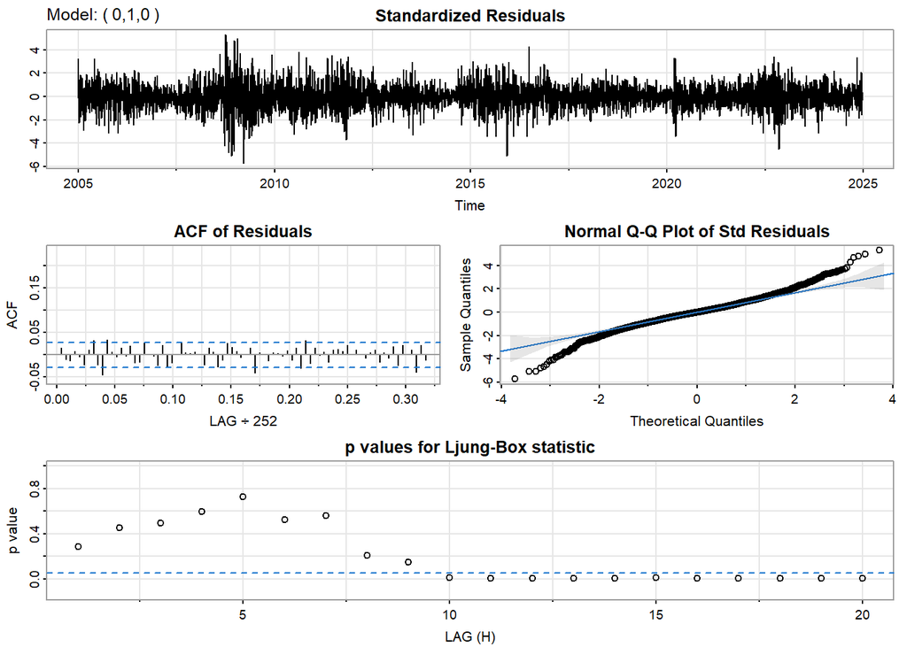

```r
model_output <- capture.output(sarima(dxy_ts, 0,1,0))
```

```r
start_line <- grep("Coefficients", model_output)  # Locate where coefficient details start
end_line <- length(model_output)  # Last line of output
cat(model_output[start_line:end_line], sep = "\n")
```

```
Coefficients:
         Estimate    SE t.value p.value
constant    1e-04 1e-04  0.8257   0.409

sigma^2 estimated as 2.26922e-05 on 5034 degrees of freedom

AIC = -7.854818  AICc = -7.854818  BIC = -7.852226
```

`SARIMA(0,1,0)(1,0,0)[52]`

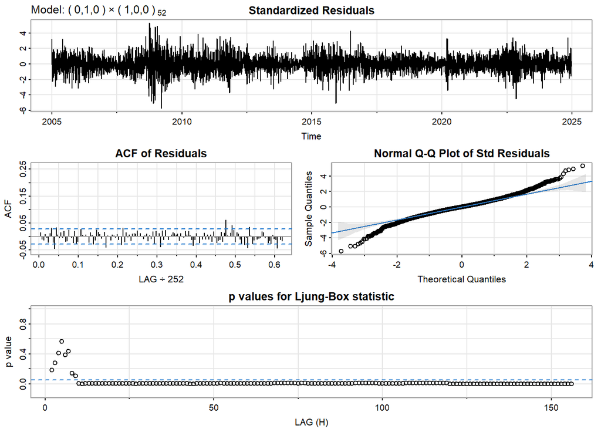

```r
model_output <- capture.output(sarima(dxy_ts, 0,1,0,1,0,0,52))
```

```r
start_line <- grep("Coefficients", model_output)  # Locate where coefficient details start
end_line <- length(model_output)  # Last line of output
cat(model_output[start_line:end_line], sep = "\n")
```

```
Coefficients:
         Estimate     SE t.value p.value
sar1       0.0163 0.0142   1.148  0.2510
constant   0.0001 0.0001   0.813  0.4162

sigma^2 estimated as 2.26862e-05 on 5033 degrees of freedom

AIC = -7.854682  AICc = -7.854682  BIC = -7.850795
```

**Trade Balance**

`SARIMA(0,1,1)x(0,1,1)[4]`

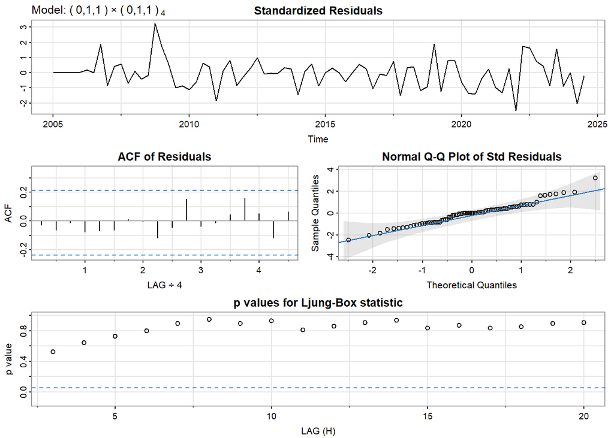

```r
model_output <- capture.output(sarima(balance_ts, 0,1,1,0,1,1,4))
```

```r
start_line <- grep("Coefficients", model_output)  # Locate where coefficient details start
end_line <- length(model_output)  # Last line of output
cat(model_output[start_line:end_line], sep = "\n")
```

```
Coefficients:
     Estimate     SE t.value p.value
ma1    0.3818 0.1180  3.2370  0.0018
sma1  -1.0000 0.1779 -5.6216  0.0000

sigma^2 estimated as 186141279 on 72 degrees of freedom

AIC = 22.12418  AICc = 22.12647  BIC = 22.21759
```

`SARIMA(1,0,1)(2,1,0)[4]`

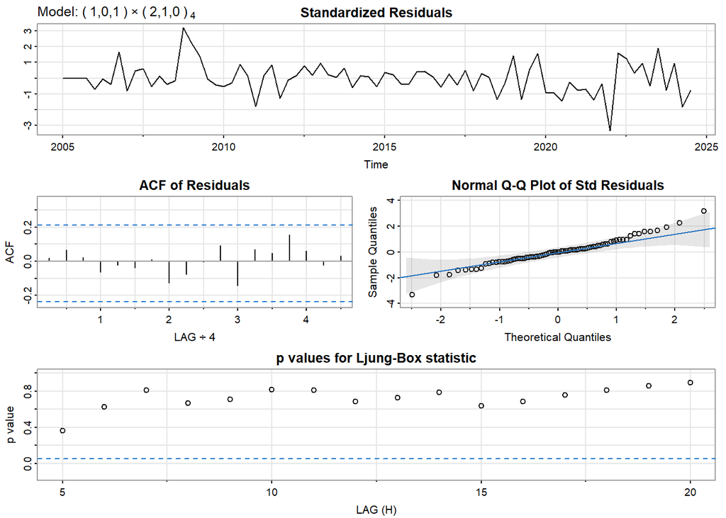

```r
model_output <- capture.output(sarima(balance_ts, 1,0,1,2,1,0,4))
```

```r
start_line <- grep("Coefficients", model_output)  # Locate where coefficient details start
end_line <- length(model_output)  # Last line of output
cat(model_output[start_line:end_line], sep = "\n")
```

```
Coefficients:
          Estimate        SE t.value p.value
ar1         0.7876    0.0818  9.6289  0.0000
ma1         0.4443    0.1215  3.6567  0.0005
sar1       -0.6792    0.1224 -5.5499  0.0000
sar2       -0.2852    0.1254 -2.2749  0.0260
constant -726.8264 1479.2954 -0.4913  0.6247

sigma^2 estimated as 226334013 on 70 degrees of freedom

AIC = 22.2794  AICc = 22.29099  BIC = 22.4648
```

**GDP**

`ARIMA(0,1,0)`

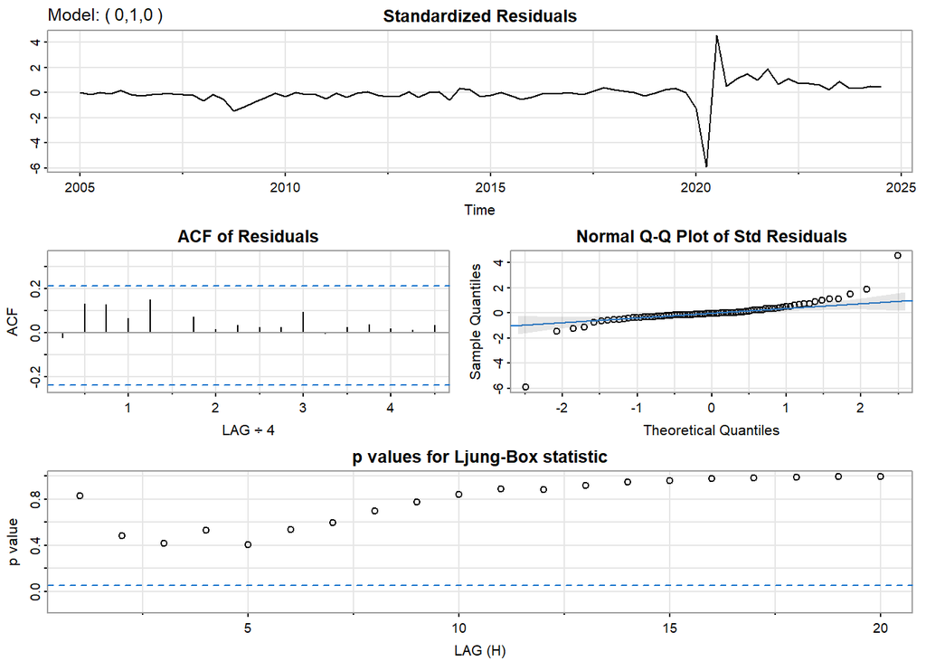

```r
model_output <- capture.output(sarima(gdp_ts, 0,1,0))
```

```r
start_line <- grep("Coefficients", model_output)  # Locate where coefficient details start
end_line <- length(model_output)  # Last line of output
cat(model_output[start_line:end_line], sep = "\n")
```

```
Coefficients:
         Estimate      SE t.value p.value
constant 212.9192 38.3573  5.5509       0

sigma^2 estimated as 114760 on 77 degrees of freedom

AIC = 14.53976  AICc = 14.54043  BIC = 14.60019
```

`ARIMA(0,2,1)`

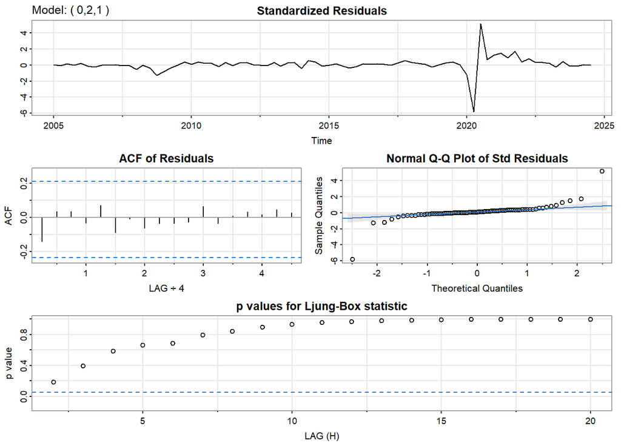

```r
model_output <- capture.output(sarima(gdp_ts, 0,2,1))
```

```r
start_line <- grep("Coefficients", model_output)  # Locate where coefficient details start
end_line <- length(model_output)  # Last line of output
cat(model_output[start_line:end_line], sep = "\n")
```

```
Coefficients:
    Estimate     SE  t.value p.value
ma1   -0.921 0.0442 -20.8594       0

sigma^2 estimated as 113730.5 on 76 degrees of freedom

AIC = 14.5559  AICc = 14.55659  BIC = 14.61677
```

**Unemployment Rate**

`ARIMA(0,1,0)`

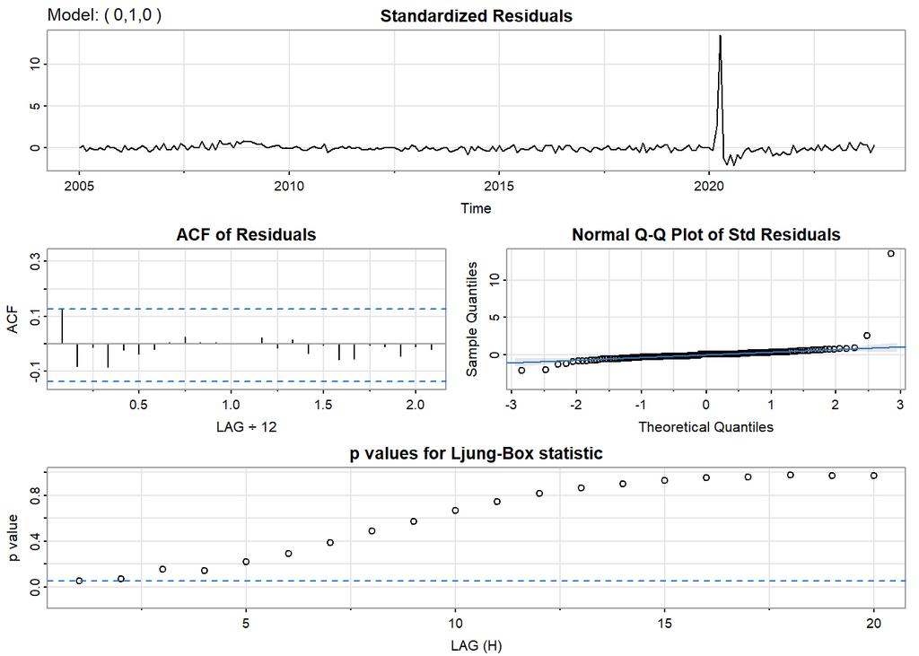

```r
model_output <- capture.output(sarima(unem_ts, 0,1,0))
```

```r
start_line <- grep("Coefficients", model_output)  # Locate where coefficient details start
end_line <- length(model_output)  # Last line of output
cat(model_output[start_line:end_line], sep = "\n")
```

```
Coefficients:
         Estimate    SE t.value p.value
constant  -0.0015 0.006  -0.246  0.8059

sigma^2 estimated as 0.008057314 on 226 degrees of freedom

AIC = -1.965677  AICc = -1.965598  BIC = -1.935501
```

`ARIMA(1,1,1)`

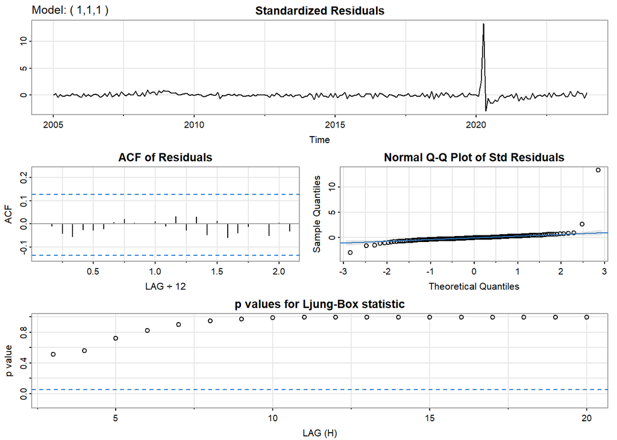

```r
model_output <- capture.output(sarima(unem_ts, 1,1,1))
```

```r
start_line <- grep("Coefficients", model_output)  # Locate where coefficient details start
end_line <- length(model_output)  # Last line of output
cat(model_output[start_line:end_line], sep = "\n")
```

```
Coefficients:
         Estimate     SE t.value p.value
ar1       -0.5485 0.2146 -2.5556  0.0113
ma1        0.6962 0.1832  3.7993  0.0002
constant  -0.0014 0.0064 -0.2196  0.8264

sigma^2 estimated as 0.007811542 on 224 degrees of freedom

AIC = -1.978774  AICc = -1.9783  BIC = -1.918423
```

`ARIMA(0,1,1)`

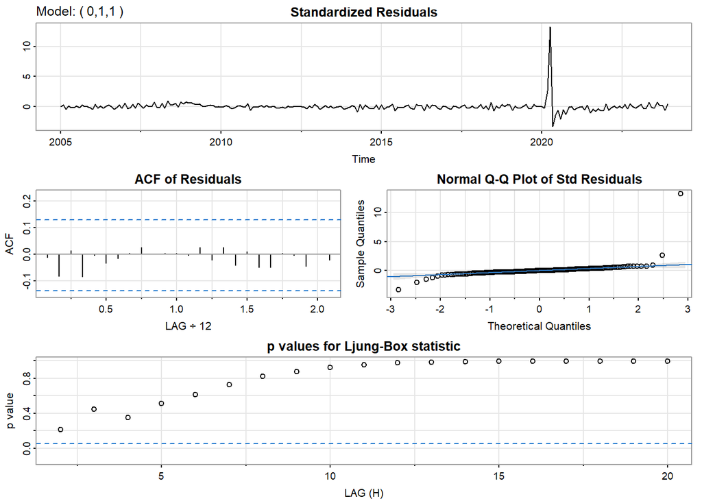

```r
model_output <- capture.output(sarima(unem_ts, 0,1,1))
```

```r
start_line <- grep("Coefficients", model_output)  # Locate where coefficient details start
end_line <- length(model_output)  # Last line of output
cat(model_output[start_line:end_line], sep = "\n")
```

```
Coefficients:
         Estimate     SE t.value p.value
ma1        0.1550 0.0722  2.1459  0.0329
constant  -0.0014 0.0068 -0.2091  0.8345

sigma^2 estimated as 0.00789841 on 225 degrees of freedom

AIC = -1.976678  AICc = -1.976442  BIC = -1.931414
```

**CPI**

`SARIMA(1,1,2)x(0,1,1)[12]`

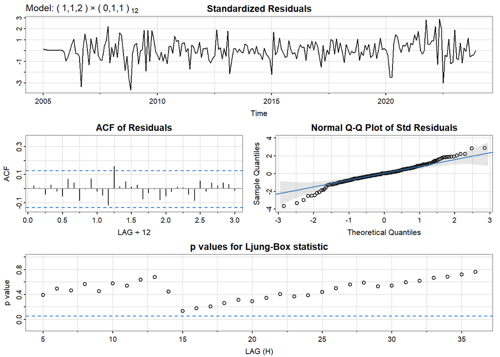

```r
model_output <- capture.output(sarima(cpi_ts, 1,1,2,0,1,1,12))
```

```r
start_line <- grep("Coefficients", model_output)  # Locate where coefficient details start
end_line <- length(model_output)  # Last line of output
cat(model_output[start_line:end_line], sep = "\n")
```

```
Coefficients:
     Estimate     SE t.value p.value
ar1    0.9485 0.0611 15.5239  0.0000
ma1   -0.3778 0.0934 -4.0438  0.0001
ma2   -0.4161 0.0769 -5.4148  0.0000
sma1  -0.9915 1.1241 -0.8820  0.3788

sigma^2 estimated as 0.4663129 on 211 degrees of freedom

AIC = 2.275082  AICc = 2.275968  BIC = 2.353469
```

`SARIMA(2,2,3)(1,0,0)[12]`

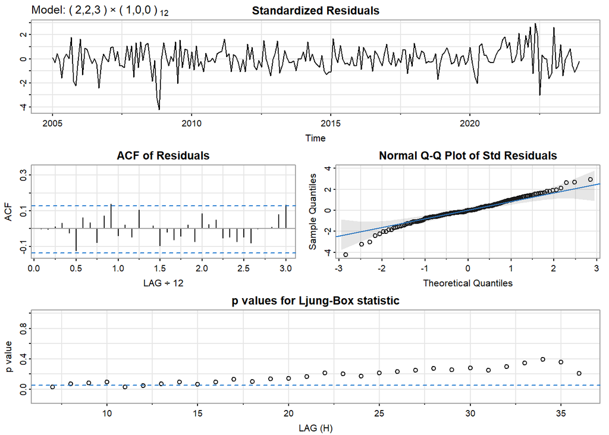

```r
model_output <- capture.output(sarima(cpi_ts, 2,2,3,1,0,0,12))
```

```r
start_line <- grep("Coefficients", model_output)  # Locate where coefficient details start
end_line <- length(model_output)  # Last line of output
cat(model_output[start_line:end_line], sep = "\n")
```

```
Coefficients:
     Estimate     SE t.value p.value
ar1   -0.0209 0.7971 -0.0262  0.9791
ar2    0.0458 0.2766  0.1656  0.8686
ma1   -0.3448 0.7938 -0.4343  0.6645
ma2   -0.4849 0.5391 -0.8995  0.3694
ma3   -0.1413 0.2840 -0.4976  0.6193
sar1   0.2485 0.0702  3.5403  0.0005

sigma^2 estimated as 0.5989571 on 220 degrees of freedom

AIC = 2.400257  AICc = 2.401955  BIC = 2.506203
```

**S&P 500**

`ARIMA(4,1,4)`

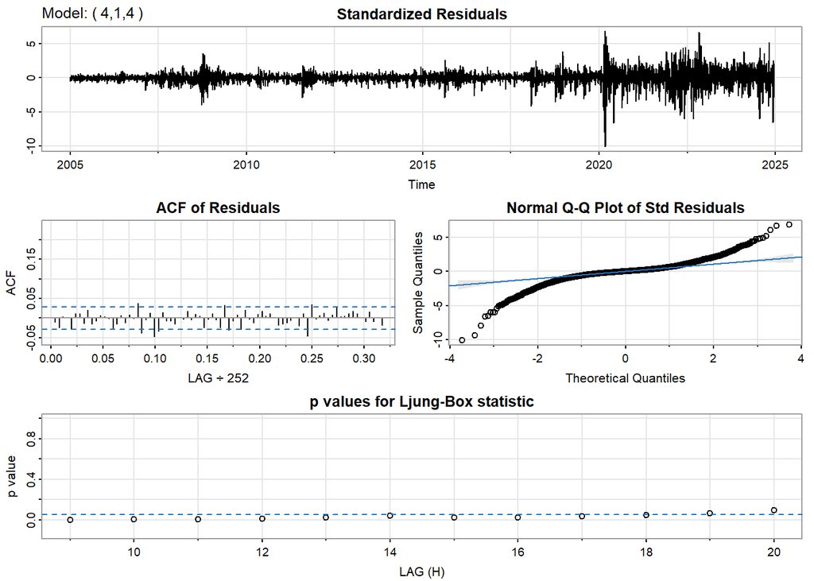

```r
model_output <- capture.output(sarima(sp5_ts, 4,1,4))
```

```r
start_line <- grep("Coefficients", model_output)  # Locate where coefficient details start
end_line <- length(model_output)  # Last line of output
cat(model_output[start_line:end_line], sep = "\n")
```

```
Coefficients:
         Estimate     SE  t.value p.value
ar1       -0.2465 0.0268  -9.2149  0.0000
ar2        0.7864 0.0223  35.2752  0.0000
ar3       -0.3998 0.0198 -20.1590  0.0000
ar4       -0.8560 0.0262 -32.6906  0.0000
ma1        0.1942 0.0334   5.8183  0.0000
ma2       -0.7627 0.0273 -27.9744  0.0000
ma3        0.4428 0.0244  18.1189  0.0000
ma4        0.7686 0.0328  23.4248  0.0000
constant   0.9567 0.3778   2.5323  0.0114

sigma^2 estimated as 783.1994 on 5022 degrees of freedom

AIC = 9.505299  AICc = 9.505306  BIC = 9.518265
```

`ARIMA(5,2,0)`

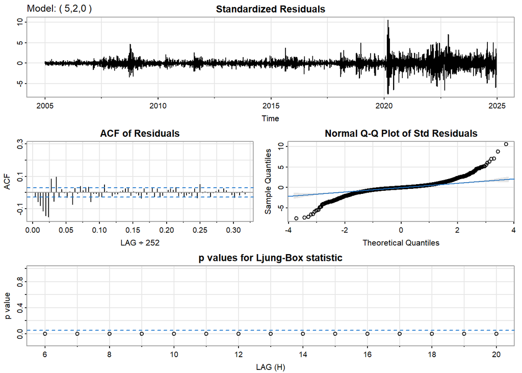

```r
model_output <- capture.output(sarima(sp5_ts, 5,2,0))
```

```r
start_line <- grep("Coefficients", model_output)  # Locate where coefficient details start
end_line <- length(model_output)  # Last line of output
cat(model_output[start_line:end_line], sep = "\n")
```

```
Coefficients:
    Estimate     SE  t.value p.value
ar1  -0.8897 0.0140 -63.5255       0
ar2  -0.6626 0.0183 -36.2866       0
ar3  -0.4855 0.0194 -25.0734       0
ar4  -0.3295 0.0183 -18.0316       0
ar5  -0.1257 0.0140  -8.9664       0

sigma^2 estimated as 958.1395 on 5025 degrees of freedom

AIC = 9.705463  AICc = 9.705465  BIC = 9.713244
```

**Gold Price**

`ARIMA(0,1,0)`

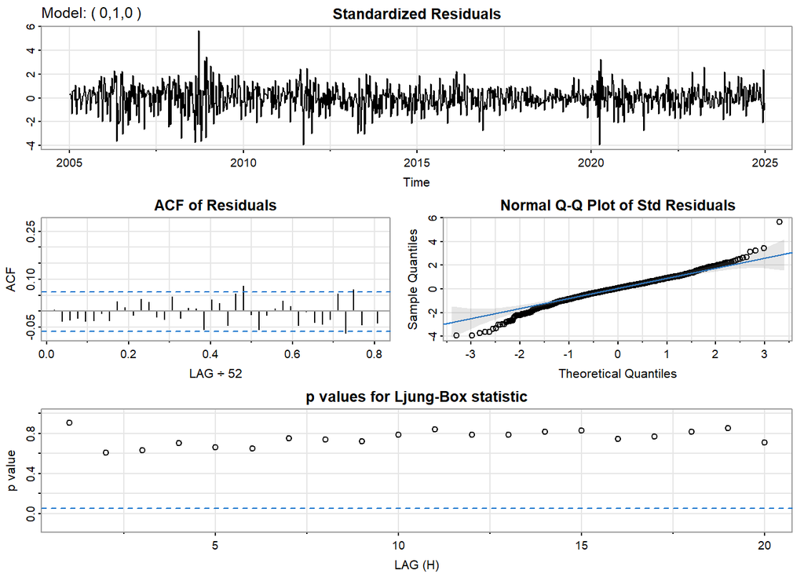

```r
model_output <- capture.output(sarima(xau_ts, 0,1,0))
```

```r
start_line <- grep("Coefficients", model_output)  # Locate where coefficient details start
end_line <- length(model_output)  # Last line of output
cat(model_output[start_line:end_line], sep = "\n")
```

```
Coefficients:
         Estimate    SE t.value p.value
constant   0.0018 7e-04  2.4406  0.0148

sigma^2 estimated as 0.0005449249 on 1038 degrees of freedom

AIC = -4.673136  AICc = -4.673132  BIC = -4.663615
```

**Global Commodity Price**

`ARIMA(0,1,0)`

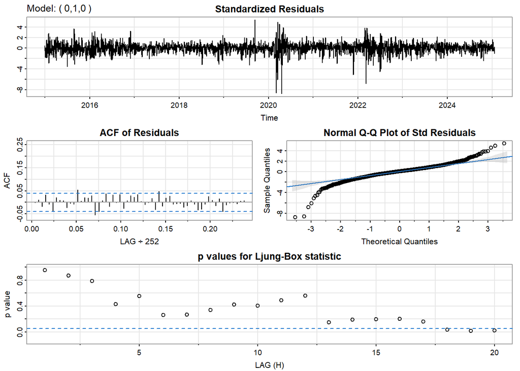

```r
model_output <- capture.output(sarima(gsci_ts, 0,1,0))
```

```r
start_line <- grep("Coefficients", model_output)  # Locate where coefficient details start
end_line <- length(model_output)  # Last line of output
cat(model_output[start_line:end_line], sep = "\n")
```

```
Coefficients:
         Estimate    SE t.value p.value
constant    1e-04 3e-04  0.4152   0.678

sigma^2 estimated as 0.0002048122 on 2534 degrees of freedom

AIC = -5.653962  AICc = -5.653961  BIC = -5.649356
```

`SARIMA(0,1,0)(1,0,0)[252]`

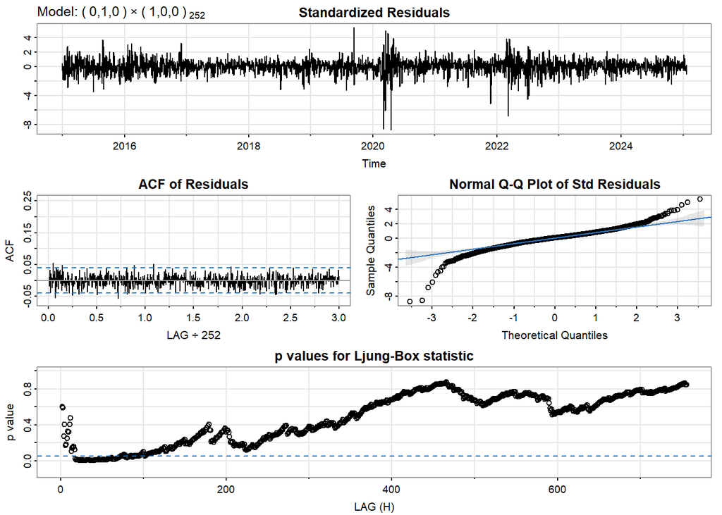

```r
model_output <- capture.output(sarima(gsci_ts, 0,1,0,1,0,0,252))
```

```r
start_line <- grep("Coefficients", model_output)  # Locate where coefficient details start
end_line <- length(model_output)  # Last line of output
cat(model_output[start_line:end_line], sep = "\n")
```

```
Coefficients:
         Estimate     SE t.value p.value
sar1       0.0073 0.0205  0.3552  0.7225
constant   0.0001 0.0003  0.4089  0.6826

sigma^2 estimated as 0.000204801 on 2533 degrees of freedom

AIC = -5.653223  AICc = -5.653221  BIC = -5.646314
```

**House Price**

`ARIMA(3,1,0)`

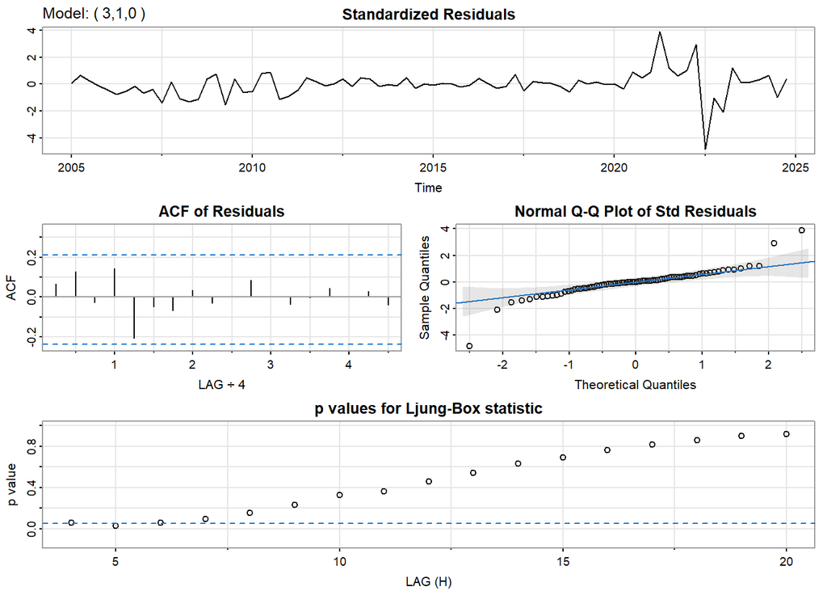

```r
model_output <- capture.output(sarima(house_ts, 3,1,0))
```

```r
start_line <- grep("Coefficients", model_output)  # Locate where coefficient details start
end_line <- length(model_output)  # Last line of output
cat(model_output[start_line:end_line], sep = "\n")
```

```
Coefficients:
         Estimate     SE t.value p.value
ar1        0.8522 0.0873  9.7634  0.0000
ar2       -0.6078 0.1101 -5.5188  0.0000
ar3        0.6153 0.0870  7.0760  0.0000
constant   5.5136 3.2681  1.6871  0.0957

sigma^2 estimated as 20.62213 on 75 degrees of freedom

AIC = 6.017157  AICc = 6.023999  BIC = 6.167122
```

`ARIMA(3,1,2)`

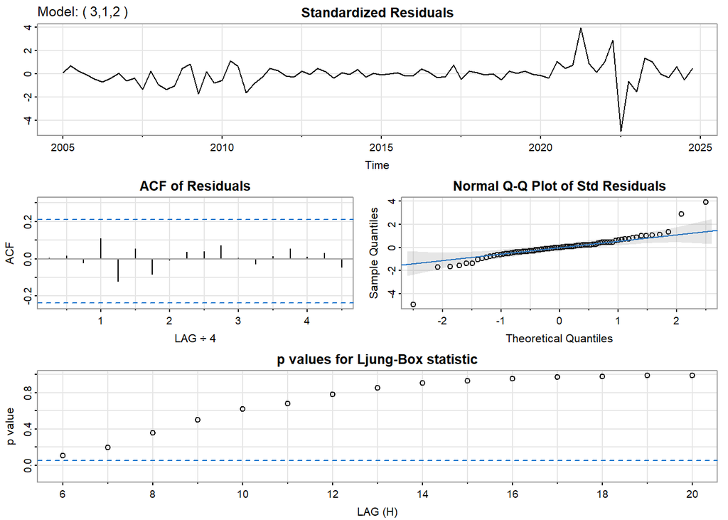

```r
model_output <- capture.output(sarima(house_ts, 3,1,2))
```

```r
start_line <- grep("Coefficients", model_output)  # Locate where coefficient details start
end_line <- length(model_output)  # Last line of output
cat(model_output[start_line:end_line], sep = "\n")
```

```
Coefficients:
         Estimate     SE t.value p.value
ar1        0.7153 0.1199  5.9658  0.0000
ar2       -0.6927 0.1109 -6.2484  0.0000
ar3        0.7350 0.0864  8.5071  0.0000
ma1        0.1982 0.1740  1.1390  0.2584
ma2        0.3248 0.1441  2.2531  0.0273
constant   5.3341 2.8926  1.8441  0.0692

sigma^2 estimated as 19.33216 on 73 degrees of freedom

AIC = 6.007442  AICc = 6.02221  BIC = 6.217393
```

`ARIMA(2,2,2)`

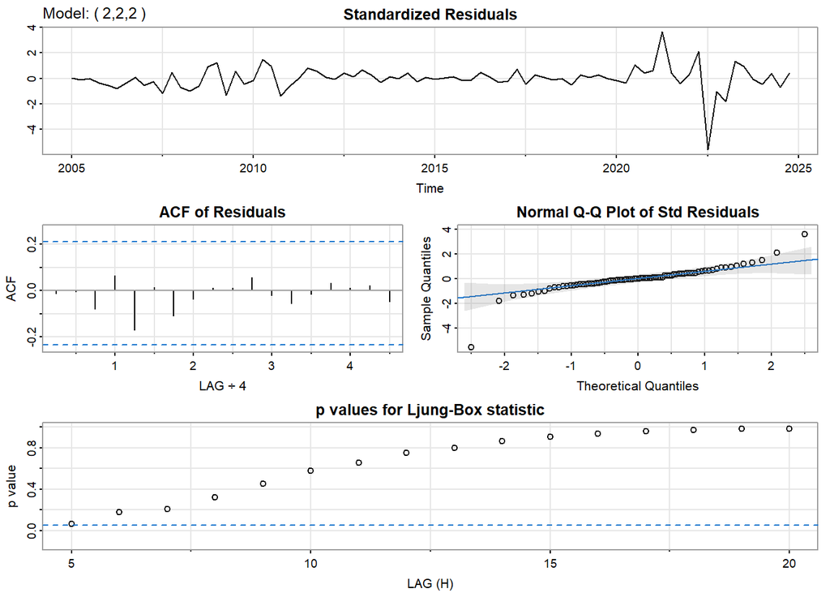

```r
model_output <- capture.output(sarima(house_ts, 2,2,2))
```

```r
start_line <- grep("Coefficients", model_output)  # Locate where coefficient details start
end_line <- length(model_output)  # Last line of output
cat(model_output[start_line:end_line], sep = "\n")
```

```
Coefficients:
    Estimate     SE t.value p.value
ar1  -0.1458 0.0917 -1.5904  0.1160
ar2  -0.8308 0.0863 -9.6271  0.0000
ma1   0.1323 0.1590  0.8321  0.4080
ma2   0.2815 0.1457  1.9323  0.0572

sigma^2 estimated as 20.58715 on 74 degrees of freedom

AIC = 6.009331  AICc = 6.016356  BIC = 6.160402
```

**International Visitors**

`SARIMA(0,1,1)x(0,1,1)[12]`

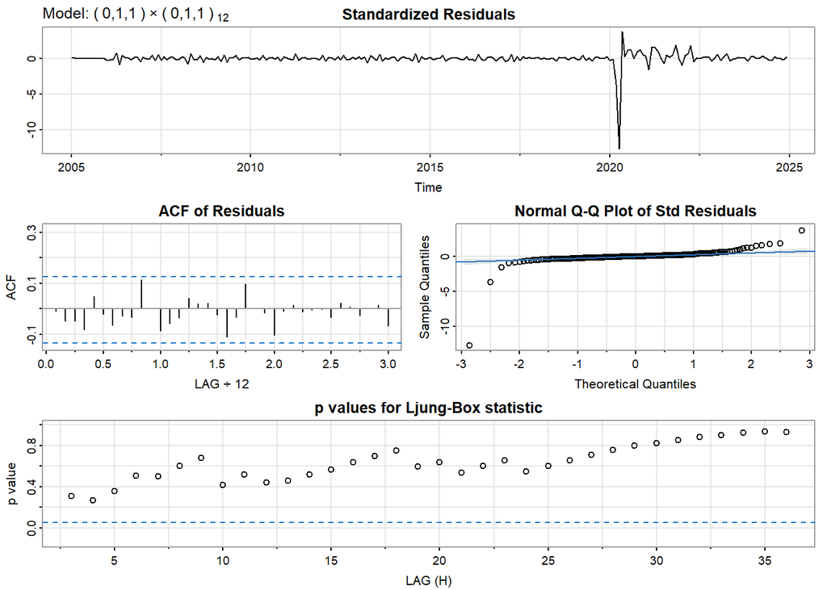

```r
model_output <- capture.output(sarima(visitors_ts, 0,1,1,0,1,1,12))
```

```r
start_line <- grep("Coefficients", model_output)  # Locate where coefficient details start
end_line <- length(model_output)  # Last line of output
cat(model_output[start_line:end_line], sep = "\n")
```

```
Coefficients:
     Estimate     SE  t.value p.value
ma1    0.2515 0.0667   3.7693   2e-04
sma1  -1.0000 0.0919 -10.8779   0e+00

sigma^2 estimated as 0.03367981 on 225 degrees of freedom

AIC = -0.3681259  AICc = -0.3678899  BIC = -0.3228623
```

`SARIMA(2,0,2)(0,0,2)[12]`

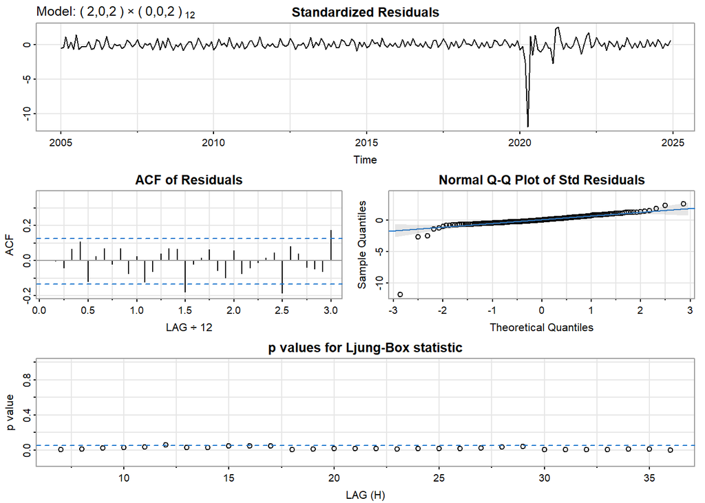

```r
model_output <- capture.output(sarima(visitors_ts, 2,0,2,0,0,2,12))
```

```r
start_line <- grep("Coefficients", model_output)  # Locate where coefficient details start
end_line <- length(model_output)  # Last line of output
cat(model_output[start_line:end_line], sep = "\n")
```

```
Coefficients:
      Estimate     SE t.value p.value
ar1     0.0223 0.1352  0.1647  0.8693
ar2     0.7591 0.1105  6.8687  0.0000
ma1     1.0862 0.1549  7.0138  0.0000
ma2     0.1426 0.0987  1.4442  0.1500
sma1    0.2468 0.0662  3.7273  0.0002
sma2    0.1422 0.0583  2.4375  0.0155
xmean  15.3529 0.1815 84.5983  0.0000

sigma^2 estimated as 0.0434599 on 233 degrees of freedom

AIC = -0.2186667  AICc = -0.2166552  BIC = -0.1026454
```